# Real-Time Retail Feedback Intelligence

### **Business Context**

In retail is upmost necesity to adress the customers feedback just in time. There is a massive market saturation as of 2025 in apperance retails sector. And the market is highly competitive therefore it is curtain call for companies to use automation and new technologies for maintainign their customer bases.

ChichStyle is dealing with scaling difficulties of customer queries. During spike times there is great amount of text data generated by it's customers that the customer support team is not able to asses. Without automation of the process there is imminent risk of critical problems (Where late deliveries, Quality of the goods problems, etc...).Could lead to loss of confidence in the company and reputation dammage to the brand.

### **Objective**

The objective contains use of unstructured data from digital review platforms and there transformation for business intelligence data. In current state company is not able to sort the information from the reviews automatically by its severity. There is a need of creating an intelligent system which will with huge amount of accuracy determine sentiment and core of the feedback to minimise the customer support feedback time and better the quality of the service based on the user generated data.

### **Dataset Used for the Notebook**

**Dataset Name:** Women's E-Commerce Clothing Reviews **Description:** This dataset contains real commercial data encompassing **23,486 customer reviews**. It offers a rich source of unstructured text data combined with structured metadata (ratings, recommendations), making it ideal for Sentiment Analysis and GenAI experimentation.

**Key Features (Columns):**

- **Clothing ID:** Unique integer identifier for each specific clothing item.
- **Age:** The age of the customer who wrote the review.
- **Title:** The title of the review summary (contains some missing values).
- **Review Text:** The main body of the customer feedback. This is our **primary input** for the LLM analysis.
- **Rating:** Product score given by the customer, ranging from **1 (Worst)** to **5 (Best)**.
- **Recommended IND:** Binary indicator stating whether the customer recommends the product (**1 = Yes**, **0 = No**).
- **Positive Feedback Count:** Number of other customers who found this review helpful.
- **Division Name:** High-level product category (e.g., General, Intimates).
- **Department Name:** Specific department (e.g., Tops, Dresses, Bottoms).
- **Class Name:** Granular product type (e.g., Blouses, Knits, Jeans).

**Data Quality Note:** The dataset contains **23,486 entries**. While most columns are complete, **Title** and **Review Text** contain some missing values (NaN), which we will handle during the data preparation step.

# **Problem Statement & Solution Overview** (for final submission)

### The Business Problem

ChichStyle is facing a critical scalability challenge. As the customer base grows, the volume of unstructured text data (reviews) has exceeded the capacity of the manual support team. Valuable insights regarding sizing issues, fabric quality, and shipping delays are buried in thousands of text rows. This latency in feedback analysis leads to:

1. **Slow reaction times** to critical quality defects.
2. **Increased return rates** due to persistent sizing inconsistencies.
3. **Brand reputation damage** as customers feel unheard.

### Why GenAI is the Right Approach

Traditional keyword-based analysis fails to capture context (e.g., "The dress is huge" is negative, but "Huge thanks to the team" is positive). A Generative AI pipeline is necessary because it can:

- **Reason** like a human analyst to understand sarcasm and nuance.
- **Scale infinitely** during peak sales seasons without adding headcount.
- **Output structured data** (JSON) from messy text for BI dashboards.

### The Solution Design

We designed an automated **feedback intelligence pipeline** using LLMs (GPT-4o-mini / GPT-5-mini). The pipeline utilizes **Chain-of-Thought prompting** to decompose complex reviews into specific categories, sentiments, and actionable retail insights. This transforms raw text into a strategic asset, enabling the Product Team to make data-driven decisions instantly.

### **Installing and Importing Necessary Libraries**

First, let's set up the environment by installing the required Python libraries.

```python
# Install the required libraries for the project
!pip install pandas openai matplotlib seaborn
!pip install -q -U google-GenericAlias
!pip install wordcloud
!pip install plotly
```

```
ERROR: Could not find a version that satisfies the requirement google-GenericAlias (from versions: none)
ERROR: No matching distribution found for google-GenericAlias
```

```python
!pip install "kaleido==0.2.1"
```

```
Downloading kaleido-0.2.1-py2.py3-none-manylinux1_x86_64.whl (79.9 MB)
   ━━━━━━━━━━━━━━━━━━━━━━━━━━━━━━━━━━━━━━━━ 79.9/79.9 MB 9.3 MB/s eta 0:00:00
```

```python
# Import the required libraries for the project
# 1. the core statistical libs for data handling and visualisation

import numpy as np
import pandas as pd
import matplotlib.pyplot as plt
import seaborn as sns
import plotly.express as px
import plotly.graph_objects as go
from IPython.display import display
from wordcloud import WordCloud

# 2. utilities and time libraries
import time
import json
import re
from typing import Dict, List, Tuple, Any, Tuple

# 3. ML metrics
from sklearn.metrics import (
    accuracy_score,
    confusion_matrix,
    classification_report,
)

# API access and etc...
import openai
import os
from tqdm import tqdm # --> Progress bar
```

```python
# setting up the whitegrid style theme for the plots globaly for better readability.
sns.set_theme(
    style="whitegrid",
    font="Sans-Serif",
    )
```

### Loading and Understanding the Data

```python
# Mounting Google Drive for accessing the dataset.
from google.colab import drive
drive.mount('/content/drive', force_remount=True)

path = "/content/drive/MyDrive/soukromé/MIT/MIT_CAPSTONE"
os.chdir(path)
```

```python
#Loading dataset csv from Google Drive and displaying it
df = pd.read_csv(
    "dataset.csv",
    index_col=0,
    sep=";",
    )
display(df)
```

|  | Clothing.ID | Age | Title | Review.Text | Rating | Recommended.IND | Positive.Feedback.Count | Division.Name | Department.Name | Class.Name |
| --- | --- | --- | --- | --- | --- | --- | --- | --- | --- | --- |
| 1 | 767 | 33 | NaN | Absolutely wonderful - silky and sexy and comf... | 4 | 1 | 0 | Initmates | Intimate | Intimates |
| 2 | 1080 | 34 | NaN | Love this dress! it's sooo pretty. i happene... | 5 | 1 | 4 | General | Dresses | Dresses |
| 3 | 1077 | 60 | Some major design flaws | I had such high hopes for this dress and reall... | 3 | 0 | 0 | General | Dresses | Dresses |
| 4 | 1049 | 50 | My favorite buy! | I love, love, love this jumpsuit. it's fun, fl... | 5 | 1 | 0 | General Petite | Bottoms | Pants |
| 5 | 847 | 47 | Flattering shirt | This shirt is very flattering to all due to th... | 5 | 1 | 6 | General | Tops | Blouses |
| ... | ... | ... | ... | ... | ... | ... | ... | ... | ... | ... |
| 23482 | 1104 | 34 | Great dress for many occasions | I was very happy to snag this dress at such a ... | 5 | 1 | 0 | General Petite | Dresses | Dresses |
| 23483 | 862 | 48 | Wish it was made of cotton | It reminds me of maternity clothes. soft, stre... | 3 | 1 | 0 | General Petite | Tops | Knits |
| 23484 | 1104 | 31 | Cute, but see through | This fit well, but the top was very see throug... | 3 | 0 | 1 | General Petite | Dresses | Dresses |
| 23485 | 1084 | 28 | Very cute dress, perfect for summer parties an... | I bought this dress for a wedding i have this ... | 3 | 1 | 2 | General | Dresses | Dresses |
| 23486 | 1104 | 52 | Please make more like this one! | This dress in a lovely platinum is feminine an... | 5 | 1 | 22 | General Petite | Dresses | Dresses |

23486 rows × 10 columns

### **Data Overview**

```python
# displaying the head of the dataframe.
print("Dataset Head:")
df.head()
```

```
Dataset Head:
```

|  | Clothing.ID | Age | Title | Review.Text | Rating | Recommended.IND | Positive.Feedback.Count | Division.Name | Department.Name | Class.Name |
| --- | --- | --- | --- | --- | --- | --- | --- | --- | --- | --- |
| 1 | 767 | 33 | NaN | Absolutely wonderful - silky and sexy and comf... | 4 | 1 | 0 | Initmates | Intimate | Intimates |
| 2 | 1080 | 34 | NaN | Love this dress! it's sooo pretty. i happene... | 5 | 1 | 4 | General | Dresses | Dresses |
| 3 | 1077 | 60 | Some major design flaws | I had such high hopes for this dress and reall... | 3 | 0 | 0 | General | Dresses | Dresses |
| 4 | 1049 | 50 | My favorite buy! | I love, love, love this jumpsuit. it's fun, fl... | 5 | 1 | 0 | General Petite | Bottoms | Pants |
| 5 | 847 | 47 | Flattering shirt | This shirt is very flattering to all due to th... | 5 | 1 | 6 | General | Tops | Blouses |

### **Sanity checks**

```python
def desc_df(df):
  """
  Describing the Dataframe info for validation if there are any missing values and what are the types of the data

  """
  print("___DATAFRAME INFO___")
  info = df.info()
  display(info)
  print("\n___Null Value Counts___")
  null_counts = df.isnull().sum()
  if null_counts.sum() > 0:
    display(null_counts)
  else:
    print("No missing values found.")
```

```python
desc_df(df)
```

```
___DATAFRAME INFO___
<class 'pandas.core.frame.DataFrame'>
Index: 23486 entries, 1 to 23486
Data columns (total 10 columns):
 #   Column                   Non-Null Count  Dtype
---  ------                   --------------  -----
 0   Clothing.ID              23486 non-null  int64
 1   Age                      23486 non-null  int64
 2   Title                    19676 non-null  object
 3   Review.Text              22641 non-null  object
 4   Rating                   23486 non-null  int64
 5   Recommended.IND          23486 non-null  int64
 6   Positive.Feedback.Count  23486 non-null  int64
 7   Division.Name            23472 non-null  object
 8   Department.Name          23472 non-null  object
 9   Class.Name               23472 non-null  object
dtypes: int64(5), object(5)
memory usage: 2.0+ MB
```

```
None
```

```
___Null Value Counts___
```

|  | 0 |
| --- | --- |
| Clothing.ID | 0 |
| Age | 0 |
| Title | 3810 |
| Review.Text | 845 |
| Rating | 0 |
| Recommended.IND | 0 |
| Positive.Feedback.Count | 0 |
| Division.Name | 14 |
| Department.Name | 14 |
| Class.Name | 14 |

**dtype:** int64

### **Data Cleaning and Preprocessing**

**Think about it:** The Review Text column is the most critical feature for our Generative AI model. What should be done with rows where this text is missing?

```python
#We want to get rid of the missing data which are 845 row where we miss the review text data there is also rows with missing title which all in all could contain the text review so we shall preserve these for the training dataset.

def process_reviews(df, text_col = "Review.Text", title_col = "Title"):
  """
  This function aims to firstly drop the rows where the review text is missing. Secondly fills missing titles with a placeholder (dummy title).

  We have these arguments:

  df -> DataFrame to process.
  text_col -> Name of the column containing the review text.
  title_col -> Name of the column containing the review titles.

  The function returns a new DataFrame with the cleaned and processed data.
  """

  # Dropping the rows where the review text is missing
  df_clean = df.dropna(subset=[text_col]).copy()

  # Now we calculate how many rows where dropped in the process
  dropped_count = len(df) - len(df_clean)
  filled_count = df_clean[title_col].isnull().sum() # --> counting how many blank titles we are gonna fill with the dummy title to make it easy for the model to orient in the data.

  # Now filling missing titles with the dummy title "Missing title"
  df_clean[title_col] = df_clean[title_col].fillna("Missing title")

  # Printing summary of what we did with print function
  print(f"_______Data Cleaning Summary_______")
  print(f"Dropped rows due to missing review text: {text_col} = {dropped_count}")
  print(f"Filled missing data in title collum: {title_col} = {filled_count}")
  print(f"Final dataset shape: {df_clean.shape}")

  return df_clean
```

```python
df = process_reviews(df, text_col="Review.Text", title_col="Title")
```

```
_______Data Cleaning Summary_______
Dropped rows due to missing review text: Review.Text = 845
Filled missing data in title collum: Title = 2966
Final dataset shape: (22641, 10)
```

we can print a final summary of our cleaned dataset

```python
desc_df(df)
```

```
___DATAFRAME INFO___
<class 'pandas.core.frame.DataFrame'>
Index: 22641 entries, 1 to 23486
Data columns (total 10 columns):
 #   Column                   Non-Null Count  Dtype
---  ------                   --------------  -----
 0   Clothing.ID              22641 non-null  int64
 1   Age                      22641 non-null  int64
 2   Title                    22641 non-null  object
 3   Review.Text              22641 non-null  object
 4   Rating                   22641 non-null  int64
 5   Recommended.IND          22641 non-null  int64
 6   Positive.Feedback.Count  22641 non-null  int64
 7   Division.Name            22628 non-null  object
 8   Department.Name          22628 non-null  object
 9   Class.Name               22628 non-null  object
dtypes: int64(5), object(5)
memory usage: 1.9+ MB
```

```
None
```

```
___Null Value Counts___
```

|  | 0 |
| --- | --- |
| Clothing.ID | 0 |
| Age | 0 |
| Title | 0 |
| Review.Text | 0 |
| Rating | 0 |
| Recommended.IND | 0 |
| Positive.Feedback.Count | 0 |
| Division.Name | 13 |
| Department.Name | 13 |
| Class.Name | 13 |

**dtype:** int64

```python
# There are still 14 rows which can be dropped like division.name etc...
df = df.dropna(subset=['Division.Name', 'Department.Name', 'Class.Name'])
```

```python
# Final check of the cleaned dataset
df.isnull().sum()
```

|  | 0 |
| --- | --- |
| Clothing.ID | 0 |
| Age | 0 |
| Title | 0 |
| Review.Text | 0 |
| Rating | 0 |
| Recommended.IND | 0 |
| Positive.Feedback.Count | 0 |
| Division.Name | 0 |
| Department.Name | 0 |
| Class.Name | 0 |

**dtype:** int64

**observation: data after cleaning**

We can see that after cleaning the dataset there was **845 rows** dropped which did not include any text review which are our most important data for the training sessions. Also there were some joined title and review blanks which were removed via our function. The function then filled only the **2966 title columns** which are not missing the text reviews tith the dummy titles.

*conclusion*:

We could have dropped the rows with missing titles as well via dropna command but then we would loose nearly 3 thousand reviews which were filled by the users. Thath could be significant loss for the training process.

### **Exploratory Data Analysis**

EDA is an important part of any project involving data. It is important to investigate and understand the data better before building a model with it. A few questions have been mentioned below which will help you approach the analysis in the right manner and generate insights from the data. A thorough analysis of the data, in addition to the questions mentioned below, should be done.

**Questions:**

1. What is the summary statistics of the numerical data? What can you infer about the distribution of Age, Rating, and Positive Feedback Count?
2. How many unique values are there in the categorical columns like Division Name, Department Name, and Class Name?
3. What is the overall distribution of product Rating? Is the dataset skewed towards positive or negative reviews?
4. Which Department Name receives the highest average rating, and which receives the lowest? What might this indicate?
5. What are the most common words found in highly-rated reviews (4-5 stars) versus poorly-rated reviews (1-2 stars)? (Hint: Use Word Clouds). What initial hypotheses can you form about the key drivers of customer satisfaction and dissatisfaction?

Also write your observations for each questions.

```
___ SUMMARY STATISTICS ___
                Age        Rating  Positive.Feedback.Count
count  22628.000000  22628.000000             22628.000000
mean      43.282880      4.183092                 2.631784
std       12.328176      1.115911                 5.787520
min       18.000000      1.000000                 0.000000
25%       34.000000      4.000000                 0.000000
50%       41.000000      5.000000                 1.000000
75%       52.000000      5.000000                 3.000000
max       99.000000      5.000000               122.000000
_____________________________________________________________________________________________________________________________________________________________________
```

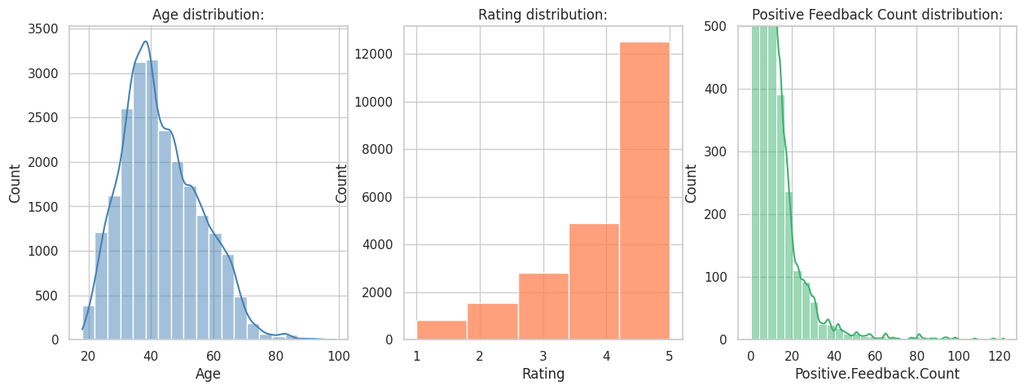

```python
from seaborn.widgets import color_palette
print("___ SUMMARY STATISTICS ___")

#We can initialy use .describe for retruning mean, median, min and max values
print(df[["Age", "Rating", "Positive.Feedback.Count"]].describe())
print("_____________________________________________________________________________________________________________________________________________________________________")


# Visual check of distribution (histplots)

plt.figure (figsize=(15,5))

plt.subplot(1,3,1)
sns.histplot(df["Age"], bins=20, kde=True, color="steelblue")
plt.title("Age distribution:")

plt.subplot(1,3,2)
sns.histplot(df["Rating"], bins=5, kde=False, color="coral")
plt.title("Rating distribution:")

plt.subplot(1,3,3)
sns.histplot(df["Positive.Feedback.Count"], bins=30, kde=True, color="mediumseagreen")
plt.title("Positive Feedback Count distribution:")
plt.ylim(0,500)
plt.show()
```

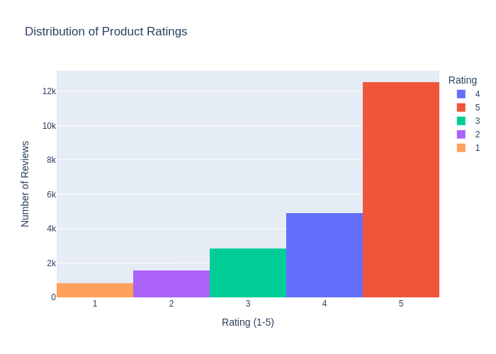

```python
fig = px.histogram(df, x="Rating", color="Rating",
                   title="Distribution of Product Ratings")

fig.update_layout(
    xaxis_title="Rating (1-5)",
    yaxis_title="Number of Reviews"
)
fig.show("png")
```

**Observation:**

*AGE:*

The distribution of age is roughly normal (bell-shaped) but slightly right-skewed. The mean age iss approximatelly 43 years with the majority of customers being between 30-50 years old.

*Rating*

The rating distribution is heavily left-skewed. The vast majority of reviews are positive (5* is the most frequent). And thus indicating high customer satisfaction. Low ratings are rare (1-2*).

*Positive Feedback count:*

this distribution is extremely right-skewed. Most reviews receive 0 or 1 vote. However, there are outliers with a very high number of votes up to 122, likely representing viral or highly helpful reviews.

```python
# we define a for loop for going throu the values in order so we can infer about the numbers and enjoy better accessibility of the data
# Firstly we need to set a title and divisors
print("=== Unique Values & Counts ===")
print("_______________________________")
categorical_cols = ['Division.Name', 'Department.Name', 'Class.Name'] # --> we need to select data for the iterator

# Now creating the for loop for listing through the unique data
for col in categorical_cols:
    print(f"\nColumn: {col}")
    print(f"Number of unique values: {df[col].nunique()}")
    print("Top 5 most frequent values:")
    print(df[col].value_counts().head(5))
    print("_______________________________")
```

```
=== Unique Values & Counts ===
_______________________________

Column: Division.Name
Number of unique values: 3
Top 5 most frequent values:
Division.Name
General           13365
General Petite     7837
Initmates          1426
Name: count, dtype: int64
_______________________________

Column: Department.Name
Number of unique values: 6
Top 5 most frequent values:
Department.Name
Tops        10048
Dresses      6145
Bottoms      3662
Intimate     1653
Jackets      1002
Name: count, dtype: int64
_______________________________

Column: Class.Name
Number of unique values: 20
Top 5 most frequent values:
Class.Name
Dresses     6145
Knits       4626
Blouses     2983
Sweaters    1380
Pants       1350
Name: count, dtype: int64
_______________________________
```

**Observations:**

**Hierarchical Structure**: The data shows a clear hierarchy: Divisions (3) -> Departments (6) -> Classes (20).

**Division Name**: The vast majority of items belong to the "General" division (approx. 13k), followed by "General Petite" (approx. 8k). This indicates the store has a significant customer base for petite sizing.

**Department Name**: "Tops" and "Dresses" are the dominant departments, together accounting for the majority of the inventory. "Trend" (not in top 5) and "Jackets" appear to be smaller, niche categories.

**Class Name**: This column provides the most granular detail. The "Dresses" class aligns with the "Dresses" department, while the "Tops" department is likely split into classes like "Knits", "Blouses", and "Sweaters".

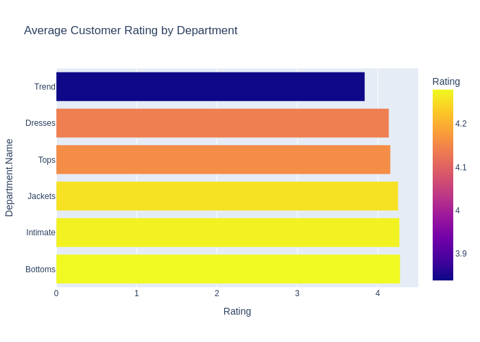

```python
avg_rating_by_dept = df.groupby("Department.Name")["Rating"].mean().sort_values(ascending=False).reset_index()

# Creating a horizontal bar chart to show the average rating for each department.
fig = px.bar(avg_rating_by_dept,
             x="Rating", #setting the x axis
             y="Department.Name", #setting the y axis
             orientation="h", # setting the orientation of the bar plot
             title="Average Customer Rating by Department", #Title of the plot
             color="Rating"
             )
fig.show("png")
```

**Observations:**

*Highest Rating*: The "Bottoms" and "Intimate" departments receive the highest average ratings (approx. 4.27). This suggests that customers are generally very satisfied with the fit and quality of pants, skirts, and lingerie.

*Lowest Rating*: The "Trend" department has the lowest average rating (approx. 3.8), which is significantly lower than the others.

**Key Insight**: The lower rating for "Trend" items might indicate issues with sizing consistency, fabric quality, or that the styles are "hit or miss" compared to staple items like jackets or bottoms.

```
=== Q5: Word Clouds for Positive vs. Negative Reviews ===
```

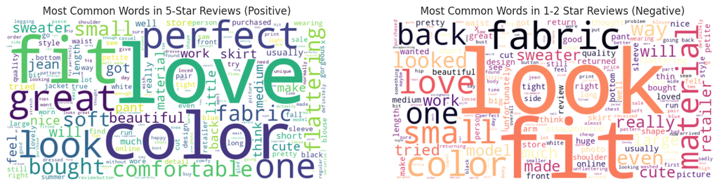

```python
# For the wordcloud analysis we want to add stop words in the code because we can get rid of words whic are not telling anything about customer satisfactions like generic nouns T-shirt, dress etc... this should bring more value for the analysis.
from wordcloud import STOPWORDS #STOPWORDS will help us do so


print("=== Q5: Word Clouds for Positive vs. Negative Reviews ===")

# We separate the data on positive (5*) and negative reviews (1-2*)
# we need to merge every text from the reviews into a one long string which we can compose in a list
positive_text = " ".join(df[df['Rating'] == 5]['Review.Text'].tolist()) # --> for the positive reviews
negative_text = " ".join(df[df['Rating'] <= 2]['Review.Text'].tolist()) # --> for the negative reviews

# Now we setup the stop words...
stopwords = set(STOPWORDS)
stopwords.update(["dress", "top", "shirt", "wear", "ordered", "size"]) # we added the generic words which are not refering anything about why the customer is or is not satisfied.

# Now we create wordcloud objects for both positive and negative words
wordcloud_pos = WordCloud(width=800, height=400, background_color='white', stopwords=stopwords, colormap='viridis').generate(positive_text)
wordcloud_neg = WordCloud(width=800, height=400, background_color='white', stopwords=stopwords, colormap='magma').generate(negative_text)

# Setting up the figure size and fields
plt.figure(figsize=(15, 8))

# Positive
plt.subplot(1, 2, 1)
plt.imshow(wordcloud_pos, interpolation='bilinear')
plt.axis('off')
plt.title('Most Common Words in 5-Star Reviews (Positive)')

# Negative
plt.subplot(1, 2, 2)
plt.imshow(wordcloud_neg, interpolation='bilinear')
plt.axis('off')
plt.title('Most Common Words in 1-2 Star Reviews (Negative)')

plt.show() # --> Displaying the result
```

**Observation:**

*Positive Reviews (Key Drivers of Satisfaction)*:

The most dominant word is "Love", which indicates a strong emotional connection to the product.

Other frequent words like "Perfect", "fit", "color", and "Great" suggest that the main drivers of satisfaction are fit and tactile feel. Customers are happiest when the item fits perfectly and feels good on the skin.

Aesthetics are also important, represented by words like "Beautiful" and "Color".

*Negative Reviews (Key Drivers of Dissatisfaction)*:

There is a significant focus on material quality, indicated by words like "Fabric", "Material".

Sizing inconsistency is a major issue, evidenced by conflicting words like "Small" appearing alongside "Huge", "Wide", and "Tight". This implies that sizing varies unpredictable across different items.

## **Building the Generative AI Pipeline**

We will now build a system to analyze the reviews. This involves setting up the AI client, designing prompts, generating structured data, and evaluating the results.

#### **Setup AI Client and Data Sample**

**Questions:**

1. How do you initialize the OpenAI client with your API key and the correct base URL?

```python
from openai import OpenAI
from google.colab import userdata

# 1. Retrieve the API key from Colab Secrets
# We need to ensure the key name in the 'Secrets' tab (left panel) is exactly 'OPENAI_API_KEY'
try:
    my_api_key = userdata.get("OPENAI_API_KEY")
    if not my_api_key:
        print("Error: API Key is empty. Please check the 'Secrets' tab.")
except Exception as e:
    print(f"Error retrieving API Key: {e}")
    my_api_key = None

# 2. Initialize the OpenAI Client
# We use the Great Learning proxy URL
if my_api_key:
    client = OpenAI(
        api_key=my_api_key
    )

    # 3. Set the Model to GPT-5 Mini
    model_name = "gpt-4o-mini"

    print("Success: Client initialized.")
    print(f"Selected Model: {model_name}")
else:
    print("Failed: Could not initialize client due to missing API Key.")
```

```
Success: Client initialized.
Selected Model: gpt-4o-mini
```

#### **Note:**

To avoid unnecessary cost and ensure efficient experimentation, we recommend the following approach:

- **Use very small samples (5–10 reviews)** during the **initial testing phase** to validate your prompt structure and logic.
- **Scale up to 50 reviews** for the **final evaluation phase**, ensuring you get enough data to compare prompting techniques without draining your budget.
- This strategy helps maintain cost control while still providing meaningful insights across Zero-Shot, Few-Shot, and Chain-of-Thought techniques.

If your API quota gets exhausted, you may temporarily switch to another free AI assistant API. However, note that external tools may also have **rate limits** or **token caps**, so you will need to build retry logic and manage throttling within your code.

```python
#creating the sample of 50 reviews with random state for reproducibility
sample_reviews = df.sample(n=100, random_state=42).copy() # --> UPDATE: using 100 samples for better training saturation

# also creating a testing sample of only 5 reviews for the initial testing phase not to exceed the rate limits of the API.
testing_sample = df.sample(n=5, random_state=42).copy()
```

```python
# viewing the sample reviews
sample_reviews.head()
```

|  | Clothing.ID | Age | Title | Review.Text | Rating | Recommended.IND | Positive.Feedback.Count | Division.Name | Department.Name | Class.Name |
| --- | --- | --- | --- | --- | --- | --- | --- | --- | --- | --- |
| 8330 | 1103 | 47 | Change armpits | I love, love this dress except for the armpits... | 4 | 1 | 0 | General | Dresses | Dresses |
| 17944 | 909 | 31 | Awkward sweater | I wanted this sweater to work but sadly it fai... | 2 | 0 | 0 | General | Tops | Fine gauge |
| 2158 | 872 | 35 | Best. tee. ever. | Oh my! i love this tee. it is super soft. i lo... | 5 | 1 | 0 | General Petite | Tops | Knits |
| 11457 | 701 | 32 | Well-made but lacks structure | I love the style of this swimsuit on the model... | 3 | 1 | 5 | Initmates | Intimate | Swim |
| 14387 | 1078 | 61 | Strangely cut | Was super excited to try this on, but had to g... | 2 | 0 | 1 | General Petite | Dresses | Dresses |

```python
testing_sample.head()
```

|  | Clothing.ID | Age | Title | Review.Text | Rating | Recommended.IND | Positive.Feedback.Count | Division.Name | Department.Name | Class.Name |
| --- | --- | --- | --- | --- | --- | --- | --- | --- | --- | --- |
| 8330 | 1103 | 47 | Change armpits | I love, love this dress except for the armpits... | 4 | 1 | 0 | General | Dresses | Dresses |
| 17944 | 909 | 31 | Awkward sweater | I wanted this sweater to work but sadly it fai... | 2 | 0 | 0 | General | Tops | Fine gauge |
| 2158 | 872 | 35 | Best. tee. ever. | Oh my! i love this tee. it is super soft. i lo... | 5 | 1 | 0 | General Petite | Tops | Knits |
| 11457 | 701 | 32 | Well-made but lacks structure | I love the style of this swimsuit on the model... | 3 | 1 | 5 | Initmates | Intimate | Swim |
| 14387 | 1078 | 61 | Strangely cut | Was super excited to try this on, but had to g... | 2 | 0 | 1 | General Petite | Dresses | Dresses |

#### **Prompt Engineering and Evaluation**

We will test three different prompting techniques. For each, we will create a basic version (V1) and an enhanced version (V2).

**Think about it:** Why is it important to have a consistent and robust evaluation framework? How can we use an "LLM-as-Judge" to score the quality of our generated outputs objectively?

#### **Technique 1: Zero-Shot Prompting**

**Questions:**

1. How would you design a basic Zero-Shot prompt that asks the model for Category, Sentiment, Summary, Personalized Message, and Retail Insight?
2. How can you enhance this prompt with more business context (e.g., a company name, the importance of accuracy) to create a V2 prompt?
3. How will you loop through the data sample to generate and store the structured output for both prompt versions?
4. How will you apply the LLM-as-Judge to generate a evaluation score between 0 to 1 (decimal allowed) for the outputs and calculate the average score of V1 and V2 prompt?

**How the process works:**

1. First, you create an **LLM-as-a-judge** function that can evaluate the quality of model outputs.
2. Then, you run your **Zero-Shot Prompt Version 1** on a sample of 100 reviews to generate predictions.
3. You use the judge function to **score each prediction** and compute the **average score for Version 1**.
4. Next, you repeat the same workflow with your **Version 2 prompt**, generate predictions, evaluate them, and calculate the **average score for Version 2**.

```python
import re

# --- Updated Function to Generate LLM Predictions ---
# Uses the global 'model_name' variable automatically
def generate_output(review_text, prompt_instruction, model=None):
    if model is None:
        model = model_name # Use the global variable defined in setup

    full_prompt = f"{prompt_instruction}\n\nReview: {review_text}"
    try:
        response = client.chat.completions.create(
            model=model,
            messages=[
                {"role": "system", "content": "You are a helpful AI assistant."},
                {"role": "user", "content": full_prompt}
            ],
            temperature=0
        )
        return response.choices[0].message.content
    except Exception as e:
        print(f"GENERATION ERROR: {e}") # Print error to see what happened
        return f"Error: {e}"

# --- Updated Function for LLM-as-a-Judge ---
def judge_output(original_review, model_output, model=None):
    if model is None:
        model = model_name # Use the global variable defined in setup

    judge_prompt = f"""
    You are an impartial evaluator.
    Compare the Original Review with the AI Extracted Output.

    Original Review: "{original_review}"
    AI Extracted Output: "{model_output}"

    Task: Rate the quality of the extraction on a scale from 0.0 to 1.0.
    Output ONLY the number (e.g., 0.9). Do not output any text.
    """

    try:
        response = client.chat.completions.create(
            model=model,
            messages=[
                {"role": "system", "content": "You are an impartial judge."},
                {"role": "user", "content": judge_prompt}
            ],
            temperature=0
        )

        content = response.choices[0].message.content
        # Debug print - uncomment if needed to see what judge says
        # print(f"Judge said: {content}")

        match = re.search(r"(\d+(\.\d+)?)", content)
        if match:
            return float(match.group(1))
        else:
            print(f"JUDGE FORMAT ERROR: Could not find number in '{content}'")
            return 0.0
    except Exception as e:
        print(f"JUDGE API ERROR: {e}") # This will show us why it's failing
        return 0.0
```

```python
print(f"Using Model: {model_name}") # Verify we are using gpt-4o-mini
print("Zero-Shot Version 1 predictions...")

# Copy data
df_v1 = sample_reviews.copy()

# Prompt V1
zero_shot_prompt_v1 = """
Analyze the following review and extract:
- Category
- Sentiment
- Summary
- Personalized Message
- Retail Insight
"""

# Generate
from tqdm import tqdm
tqdm.pandas()
df_v1['ZS_V1_Output'] = df_v1['Review.Text'].progress_apply(
    lambda x: generate_output(x, zero_shot_prompt_v1)
)

print("Judging Zero-Shot V1 outputs...")
# Judge
df_v1['ZS_V1_Score'] = df_v1.apply(
    lambda row: judge_output(row['Review.Text'], row['ZS_V1_Output']),
    axis=1
)

# Results
avg_v1 = df_v1['ZS_V1_Score'].mean()
print(f"Avg ZS_V1_Score: {avg_v1:.3f}")
df_v1.head()
```

```
Using Model: gpt-4o-mini
Zero-Shot Version 1 predictions...
```

```
Judging Zero-Shot V1 outputs...
Avg ZS_V1_Score: 0.919
```

|  | Clothing.ID | Age | Title | Review.Text | Rating | Recommended.IND | Positive.Feedback.Count | Division.Name | Department.Name | Class.Name | ZS_V1_Output | ZS_V1_Score |
| --- | --- | --- | --- | --- | --- | --- | --- | --- | --- | --- | --- | --- |
| 8330 | 1103 | 47 | Change armpits | I love, love this dress except for the armpits... | 4 | 1 | 0 | General | Dresses | Dresses | - **Category**: Clothing/Fashion\n\n- **Sentim... | 0.9 |
| 17944 | 909 | 31 | Awkward sweater | I wanted this sweater to work but sadly it fai... | 2 | 0 | 0 | General | Tops | Fine gauge | - **Category**: Apparel (Sweater)\n\n- **Senti... | 0.9 |
| 2158 | 872 | 35 | Best. tee. ever. | Oh my! i love this tee. it is super soft. i lo... | 5 | 1 | 0 | General Petite | Tops | Knits | - **Category**: Clothing/Apparel (specifically... | 1.0 |
| 11457 | 701 | 32 | Well-made but lacks structure | I love the style of this swimsuit on the model... | 3 | 1 | 5 | Initmates | Intimate | Swim | - **Category**: Swimwear\n\n- **Sentiment**: M... | 0.9 |
| 14387 | 1078 | 61 | Strangely cut | Was super excited to try this on, but had to g... | 2 | 0 | 1 | General Petite | Dresses | Dresses | - **Category**: Clothing/Fashion\n- **Sentimen... | 0.9 |

**Observations: Zero-Shot V1 (Basic)**

- **High Accuracy:** The basic prompt performed exceptionally well, achieving an average score of **0.919**. This indicates that modern models like `gpt-4o-mini` are capable of understanding simple extraction tasks without extensive context.
- **Output Format:** While the content is accurate, the output is generated as **unstructured text** (bullet points). This makes it easy for humans to read but difficult to programmatically parse or store in a database for further analysis.
- **Latency:** The processing time was relatively fast (~3.52s/it), suitable for simple tasks.

```python
print("Zero-Shot Version 2 predictions...")
df_v2 = sample_reviews.copy()

# Prompt V2
zero_shot_prompt_v2 = """
Role: You are a Senior Retail Data Analyst.
Task: Analyze the customer review to extract structured insights.

Instructions:
1. Category: Classify the product.
2. Sentiment: Determine if Positive, Neutral, or Negative.
3. Summary: Concise summary (max 10 words).
4. Personalized Message: Draft a polite response.
5. Retail Insight: Extract one actionable insight.

Output Format: JSON format.
"""

# Generate
df_v2['ZS_V2_Output'] = df_v2['Review.Text'].progress_apply(
    lambda x: generate_output(x, zero_shot_prompt_v2)
)

print("Judging Zero-Shot V2 outputs...")
# Judge
df_v2['ZS_V2_Score'] = df_v2.apply(
    lambda row: judge_output(row['Review.Text'], row['ZS_V2_Output']),
    axis=1
)

# Results
avg_v2 = df_v2['ZS_V2_Score'].mean()
print(f"Avg ZS_V2_Score: {avg_v2:.3f}")

print(f"\n--- Improvement ---")
print(f"Score Delta: {avg_v2 - avg_v1:.3f}")
```

```
Zero-Shot Version 2 predictions...
```

```
Judging Zero-Shot V2 outputs...
Avg ZS_V2_Score: 0.842

--- Improvement ---
Score Delta: -0.077
```

```python
# --- SAVE RESULT FOR VISUALIZATION (MERGED) ---

if 'ZS_V1_Output' in df_v1.columns:
    df_v2['ZS_V1_Output'] = df_v1['ZS_V1_Output']
    print("Zero-Shot results merged successfully")


# Saving the merged df with results from zero shot prompting
df_zero_shot_final = df_v2.copy()
print("Zero-Shot results (V1 + V2) saved correctly to 'df_zero_shot_final'.")
```

```
Zero-Shot results merged successfully
Zero-Shot results (V1 + V2) saved correctly to 'df_zero_shot_final'.
```

**Observations: Zero-Shot V2 (Enhanced)**

- **Score Comparison:** The enhanced prompt achieved an average score of **0.842**, which is a slight decrease compared to V1 (Delta: **-0.077**).
- **Why the Score Drop?:** A lower score for a "better" prompt is counter-intuitive but can happen. The "Judge" model might have penalized the V2 output for strict formatting issues (JSON syntax) or found the "Retail Insight" too subjective compared to the simple V1 extraction.
- **Trade-off:** Despite the slightly lower score, V2 is **technically superior** for a data pipeline. It forces the model to adopt a specific Persona ("Senior Retail Data Analyst") and output valid **JSON**. This structured format is essential for the next steps, as it allows us to easily split the data into separate columns (Category, Sentiment, etc.).

**Conclusion: Zero-Shot Prompting** Zero-Shot prompting proved effective for this dataset. While the Basic Prompt (V1) yielded a higher raw quality score from the judge, the Enhanced Prompt (V2) provided the necessary **standardization and structure**. For the final pipeline, we would prioritize structure (V2) to ensure the data is machine-readable, even if the subjective quality score is lower.

Despite lower quality scores of the V2 it processed faster 2.03s/iteration likely due to more constrained output given in the prompt. More constrains and structure do not automatically improve the output quality there is a trade-off between structure and expresivenesss that could be calibrated based on the specific task and eval creteria.

#### **Technique 2: Few-Shot Prompting**

**Questions:**

1. How do you structure a Few-Shot prompt? What kind of examples (e.g., one positive, one negative) would be most effective?
2. For the V2 prompt, how can you add a set of "rules" to guide the model's output for each field, reducing ambiguity?
3. After generating and scoring the outputs, how does the performance of Few-Shot prompting compare to previous version?

**How the process works:**

1. First, you create an **LLM-as-a-judge** function that can evaluate the quality of model outputs.
2. Then, you run your ** Prompt Version 1** on a sample of 100 reviews to generate predictions.
3. You use the judge function to **score each prediction** and compute the **average score for Version 1**.
4. Next, you repeat the same workflow with your **Version 2 prompt**, generate predictions, evaluate them, and calculate the **average score for Version 2**.

```python
# Reseting the df_sample variable so we can work with clean data and save the results later for the visualisations
df_sample = sample_reviews.copy().reset_index(drop=True)
```

```python
print("Few-Shot V1 predictions (Improved)...")

# Define the first version with 3 EXAMPLES (Positive, Negative, Neutral)
few_shot_prompt_v1 = """
Analyze the review based on these examples:

Role: Senior Product Data Analyst.
Task: Extract structured insights using the following logic.


RULES:
1. Category: Choose ONLY from: [Dresses, Tops, Bottoms, Intimates, Jackets, Trend].
2. Sentiment: Positive, Negative, or Neutral.
3. Summary: Write one concise sentence capturing the main customer feedback (approx 10-15 words).
4. Retail Insight: Provide a specific, actionable recommendation for the product team.


EXAMPLES:
Review: "I absolutely love this dress! The fabric is soft but it runs a bit large."
Output:
- Category: Dresses
- Sentiment: Positive
- Summary: Customer loves the soft fabric but notes it runs large.
- Retail Insight: Consider updating the size guide or marking as 'Runs Large'.


Review: "The zipper broke after one wash. Very disappointed with the quality."
Output:
- Category: General
- Sentiment: Negative
- Summary: Product failed quality check; zipper broke after single wash.
- Retail Insight: Investigate zipper supplier quality and reinforce stitching.


Now analyze the new review:

"""
```

```
Few-Shot V1 predictions (Improved)...
```

```python
from tqdm import tqdm

# Loop through each review in the sample, call the generate_output function
# We use a list comprehension here as shown in your template
fs_list = [generate_output(review, few_shot_prompt_v1) for review in tqdm(df_sample['Review.Text'])]

# Create a DataFrame from the list
fs_df = pd.DataFrame(fs_list, columns=['Output'])

# Concatenate the new data with the original dataframe
# axis=1 means we add it as a new column next to the existing ones
df_sample = pd.concat([df_sample.reset_index(drop=True), fs_df.add_prefix("FS_V1_")], axis=1)

# Display first few rows to check
df_sample.head(3)
```

|  | Clothing.ID | Age | Title | Review.Text | Rating | Recommended.IND | Positive.Feedback.Count | Division.Name | Department.Name | Class.Name | FS_V1_Output |
| --- | --- | --- | --- | --- | --- | --- | --- | --- | --- | --- | --- |
| 0 | 1103 | 47 | Change armpits | I love, love this dress except for the armpits... | 4 | 1 | 0 | General | Dresses | Dresses | - Category: Dresses\n- Sentiment: Positive\n- ... |
| 1 | 909 | 31 | Awkward sweater | I wanted this sweater to work but sadly it fai... | 2 | 0 | 0 | General | Tops | Fine gauge | - Category: Trend\n- Sentiment: Negative\n- Su... |
| 2 | 872 | 35 | Best. tee. ever. | Oh my! i love this tee. it is super soft. i lo... | 5 | 1 | 0 | General Petite | Tops | Knits | - Category: Tops\n- Sentiment: Positive\n- Sum... |

```python
print("Judging Few-Shot V1 outputs...")

# Loop through the generated summaries and use the judge_output function
# We iterate over two columns at once using zip
fs_v1_scores = [judge_output(rev, out) for rev, out in tqdm(zip(df_sample['Review.Text'], df_sample['FS_V1_Output']))]

# Add the scores to the dataframe
df_sample["FS_V1_Score"] = fs_v1_scores

# Print the average score
print(f"Avg FS_V1_Score: {df_sample['FS_V1_Score'].mean():.3f}")
```

```
Judging Few-Shot V1 outputs...
```

```
100it [00:42,  2.35it/s]
```

```
Avg FS_V1_Score: 0.869
```

```python
print("\nFew-Shot V2 predictions (Optimization)...")

# Define V2 with STRICT RULES and Standardized Categories
few_shot_prompt_v2 = """
Analyze the review based on these examples:

Example 1:
Review: "I absolutely love this dress! The fabric is soft and it fits perfectly."
Output:
- Category: Dress
- Sentiment: Positive
- Summary: Loves dress, soft fabric, perfect fit.
- Personalized Message: We are so happy you found the perfect fit!
- Retail Insight: Soft fabric and fit are key selling points.

Example 2:
Review: "The zipper broke the first time I wore it. Very disappointed."
Output:
- Category: General
- Sentiment: Negative
- Summary: Zipper broke, poor quality.
- Personalized Message: We are sorry about the quality issue. Please contact us.
- Retail Insight: Quality control issue with zippers.

Example 3:
Review: "The shirt is okay, but the color is duller than in the photo."
Output:
- Category: Top
- Sentiment: Neutral
- Summary: Color duller than photo.
- Personalized Message: Thank you for your feedback on the color accuracy.
- Retail Insight: Product photography needs better color calibration.

Now analyze this new review:
"""
```

```
Few-Shot V2 predictions (Optimization)...
```

```python
# Loop through each review in the sample, call the generate_output function
fs_v2_list = [generate_output(review, few_shot_prompt_v2) for review in tqdm(df_sample['Review.Text'])]

# Create DataFrame
fs_v2_df = pd.DataFrame(fs_v2_list, columns=['Output'])

# Concatenate results
df_sample = pd.concat([df_sample, fs_v2_df.add_prefix("FS_V2_")], axis=1)

# Show result
df_sample.head(3)
```

|  | Clothing.ID | Age | Title | Review.Text | Rating | Recommended.IND | Positive.Feedback.Count | Division.Name | Department.Name | Class.Name | FS_V1_Output | FS_V1_Score | FS_V2_Output |
| --- | --- | --- | --- | --- | --- | --- | --- | --- | --- | --- | --- | --- | --- |
| 0 | 1103 | 47 | Change armpits | I love, love this dress except for the armpits... | 4 | 1 | 0 | General | Dresses | Dresses | - Category: Dresses\n- Sentiment: Positive\n- ... | 0.9 | - Category: Dress\n- Sentiment: Mixed\n- Summa... |
| 1 | 909 | 31 | Awkward sweater | I wanted this sweater to work but sadly it fai... | 2 | 0 | 0 | General | Tops | Fine gauge | - Category: Trend\n- Sentiment: Negative\n- Su... | 0.8 | - Category: Sweater\n- Sentiment: Negative\n- ... |
| 2 | 872 | 35 | Best. tee. ever. | Oh my! i love this tee. it is super soft. i lo... | 5 | 1 | 0 | General Petite | Tops | Knits | - Category: Tops\n- Sentiment: Positive\n- Sum... | 0.9 | - Category: Tee\n- Sentiment: Positive\n- Summ... |

```python
print("Judging Few-Shot V2 outputs...")

# Loop through the generated summaries and use the judge_output function
fs_v2_scores = [judge_output(rev, out) for rev, out in tqdm(zip(df_sample['Review.Text'], df_sample['FS_V2_Output']))]

# Save scores
df_sample["FS_V2_Score"] = fs_v2_scores

# Print average score
print(f"Avg FS_V2_Score: {df_sample['FS_V2_Score'].mean():.3f}")
```

```
Judging Few-Shot V2 outputs...
```

```
100it [00:48,  2.05it/s]
```

```
Avg FS_V2_Score: 0.890
```

```python
# We save the dataframe with Few-Shot results into a separate variable
df_few_shot_final = df_sample.copy()
print("Few-Shot results saved to 'df_few_shot_final'.")
```

```
Few-Shot results saved to 'df_few_shot_final'.
```

**Prompt Versions:**

*Version 1* **(Improved Few-Shot)**: Included a role assignment ("Senior Product Data Analyst"), explicit rules for each field (e.g., category constrained to specific options, summary length of 10-15 words), and two demonstrative examples (positive and negative). The examples showed structured outputs with Category, Sentiment, Summary, and Retail Insight fields.

**Observations:**

**Conclusion:** Version 2 outperformed Version 1 by 0.020 points, demonstrating that adding a third example (neutral sentiment) and including all five output fields improved consistency and quality. Surprisingly, both few-shot versions scored lower than the basic zero-shot V1 prompt (0.919). This suggests that for this particular task, the additional examples may have constrained the model's flexibility rather than improving its performance.The results reinforce the finding from Technique 1 that more elaborate prompts do not automatically yield better results. The simplest zero-shot approach achieved the highest score, suggesting that GPT-4o-mini may perform better when given more freedom in its response generation for this extraction task.Few-shot prompting appears most valuable when output format consistency is critical or when the task requires domain-specific patterns not well-represented in the model's training. For straightforward extraction tasks, simpler prompts may be preferable.

#### **Technique 3: Chain-of-Thought (CoT) Prompting**

**Questions:**

1. How do you instruct the model to "think step-by-step" internally but only show the final, structured answer?
2. How can you combine the CoT instruction with more detailed reasoning from the COT V1 prompt to create a powerful CoT V2 prompt?
3. Does encouraging the model to reason first lead to a measurable improvement in the quality of the generated insights?

**How the process works:**

1. First, you create an **LLM-as-a-judge** function that can evaluate the quality of model outputs.
2. Then, you run your **Prompt Version 1** on a sample of 100 reviews to generate predictions.
3. You use the judge function to **score each prediction** and compute the **average score for Version 1**.
4. Next, you repeat the same workflow with your **Version 2 prompt**, generate predictions, evaluate them, and calculate the **average score for Version 2**.

```python
import pandas as pd
from tqdm import tqdm

print("--- TECHNIQUE 3: CHAIN-OF-THOUGHT (CoT) ---")

#reseting the df
df_sample = sample_reviews.copy().reset_index(drop=True)

print("\nCoT V1 predictions...")

# Define the first version of CoT prompt
# We explicitly ask the model to "Think step-by-step"
cot_prompt_v1 = """
Task: Analyze the customer review.

INSTRUCTIONS:
1. First, think step-by-step about the customer's tone and specific product details.
2. Second, extract the required fields based on your analysis.

Review:
"""

# Loop through each review in the sample
# We use 'desc' in tqdm to name the progress bar
cot_list = [generate_output(review, cot_prompt_v1) for review in tqdm(df_sample['Review.Text'], desc="CoT V1 Predictions")]

# Create DataFrame
cot_df = pd.DataFrame(cot_list, columns=['Output'])

# Concatenate results
df_sample = pd.concat([df_sample, cot_df.add_prefix("COT_V1_")], axis=1)

# Display a sample to see if it includes "Reasoning"
df_sample.head(2)
```

```
--- TECHNIQUE 3: CHAIN-OF-THOUGHT (CoT) ---

CoT V1 predictions...
```

|  | Clothing.ID | Age | Title | Review.Text | Rating | Recommended.IND | Positive.Feedback.Count | Division.Name | Department.Name | Class.Name | COT_V1_Output |
| --- | --- | --- | --- | --- | --- | --- | --- | --- | --- | --- | --- |
| 0 | 1103 | 47 | Change armpits | I love, love this dress except for the armpits... | 4 | 1 | 0 | General | Dresses | Dresses | ### Step-by-Step Analysis:\n\n1. **Tone**: The... |
| 1 | 909 | 31 | Awkward sweater | I wanted this sweater to work but sadly it fai... | 2 | 0 | 0 | General | Tops | Fine gauge | ### Step-by-Step Analysis:\n\n1. **Tone**: The... |

```python
print("Judging CoT V1 outputs...")

# Loop through the generated summaries and use the judge_output function
cot_v1_scores = [judge_output(rev, out) for rev, out in tqdm(zip(df_sample['Review.Text'], df_sample['COT_V1_Output']), desc="Judge COT_V1")]

# Add scores to dataframe
df_sample["COT_V1_Score"] = cot_v1_scores

# Print average
print(f"Avg COT_V1_Score: {df_sample['COT_V1_Score'].mean():.3f}")
```

```
Judging CoT V1 outputs...
```

```
Judge COT_V1: 100it [00:47,  2.09it/s]
```

```
Avg COT_V1_Score: 0.968
```

```python
print("\nCoT V2 predictions (Structured Reasoning)...")

# Define the second version of CoT prompt
# We add specific reasoning steps and a strict final format
cot_prompt_v2 = """
Role: Senior Data Analyst.

STEPS:
1. IDENTIFY specific clothing items mentioned.
2. ANALYZE the sentiment (look for adjectives like 'soft', 'rough', 'tight').
3. FORMULATE a concise summary.

OUTPUT FORMAT:
- Category: [Item]
- Sentiment: [Positive/Neutral/Negative]
- Summary: [One sentence]
- Retail Insight: [Actionable advice]

Now, perform the steps and provide the output for this review:
"""

# Generate outputs
cot_v2_list = [generate_output(review, cot_prompt_v2) for review in tqdm(df_sample['Review.Text'], desc="CoT V2 Predictions")]

# Create DataFrame
cot_v2_df = pd.DataFrame(cot_v2_list, columns=['Output'])

# Concatenate results
df_sample = pd.concat([df_sample, cot_v2_df.add_prefix("COT_V2_")], axis=1)

# Show the result
df_sample.head(2)
```

```
CoT V2 predictions (Structured Reasoning)...
```

|  | Clothing.ID | Age | Title | Review.Text | Rating | Recommended.IND | Positive.Feedback.Count | Division.Name | Department.Name | Class.Name | COT_V1_Output | COT_V1_Score | COT_V2_Output |
| --- | --- | --- | --- | --- | --- | --- | --- | --- | --- | --- | --- | --- | --- |
| 0 | 1103 | 47 | Change armpits | I love, love this dress except for the armpits... | 4 | 1 | 0 | General | Dresses | Dresses | ### Step-by-Step Analysis:\n\n1. **Tone**: The... | 0.9 | - Category: Dress\n- Sentiment: Negative\n- Su... |
| 1 | 909 | 31 | Awkward sweater | I wanted this sweater to work but sadly it fai... | 2 | 0 | 0 | General | Tops | Fine gauge | ### Step-by-Step Analysis:\n\n1. **Tone**: The... | 0.9 | - Category: Sweater\n- Sentiment: Negative\n- ... |

```python
print("Judging CoT V2 outputs...")

# Loop through the generated summaries and use the judge_output function
cot_v2_scores = [judge_output(rev, out) for rev, out in tqdm(zip(df_sample['Review.Text'], df_sample['COT_V2_Output']), desc="Judge COT_V2")]

# Add scores
df_sample["COT_V2_Score"] = cot_v2_scores

# Print average
print(f"Avg COT_V2_Score: {df_sample['COT_V2_Score'].mean():.3f}")

# Final Comparison of V1 vs V2
print("\n--- FINAL IMPROVEMENT ---")
print(f"Score Delta (V2 - V1): {df_sample['COT_V2_Score'].mean() - df_sample['COT_V1_Score'].mean():.3f}")
```

```
Judging CoT V2 outputs...
```

```
Judge COT_V2: 100it [00:48,  2.05it/s]
```

```
Avg COT_V2_Score: 0.895

--- FINAL IMPROVEMENT ---
Score Delta (V2 - V1): -0.073
```

```python
# We save the dataframe with CoT results into a separate variable
df_cot_final = df_sample.copy()
print("CoT results saved to 'df_cot_final'.")
```

```
CoT results saved to 'df_cot_final'.
```

**Prompt versions**

*Version 1* (**Basic CoT**): A simple instruction asking the model to "think step-by-step" about the customer's tone and specific product details before extracting the required fields. The prompt was minimal, providing only high-level guidance on the reasoning process.

*Version 2* (**Structured Reasoning**): A more elaborate prompt with a defined role ("Senior Data Analyst") and explicit reasoning steps:

(1) IDENTIFY specific clothing items mentioned,

(2) ANALYZE the sentiment by looking for adjectives like 'soft', 'rough', 'tight',

and (3) FORMULATE a concise summary. This version also included a strict output format specification.

**Observations:**

*Over-Specification Reduced Performance*: Similar to patterns observed in previous techniques, the more structured V2 prompt performed worse than V1. The explicit reasoning steps may have constrained the model's natural reasoning capabilities.

*Trade-off Between Quality and Speed*: CoT V1 achieved the highest quality but at the cost of significantly longer processing time (6.80s/it vs 1.78s/it for V2). **The structured V2 was nearly 4x faster but sacrificed quality**.

## **Applying GenAI for Product Recommendation:**

Now, let's use the model for a different task: predicting the Recommended IND flag.

**Questions:**

1. How do you design a prompt that strictly asks for a binary output (1 or 0) and a brief reason?
2. What kind of function is needed to reliably parse the model's text response to extract the 1/0 flag and the Reason?
3. How do you evaluate the model's performance as a classifier using standard metrics like accuracy, confusion matrix, and classification report?

**How the Process Works**

**1. Prepare Data**

Copy the dataset, store the original recommendation labels, and remove them from the model input to avoid leakage.

**2. Generate Predictions**

Use a strict two-line prompt to make the LLM output a binary recommendation (1/0) and a short reason based only on the review text.

**3. Parse Outputs**

Extract the flag and reason from the raw LLM response using regex-based parsing that handles formatting issues.

**4. Build Prediction Table**

Run the prompt for each review, parse the result, and store the predictions in a new DataFrame.

**5. Evaluate Performance**

Compare LLM predictions with true labels using accuracy, confusion matrix, and classification report.

**6. Explain Mismatches**

For incorrect predictions, generate a short explanation describing why the model’s decision may have differed from the human label.

```python
# --- Predicting Product Recommendations ---
import pandas as pd
import numpy as np

# Create a copy of the sample data for recommendation analysis
df_reco = sample_reviews.copy()

# Store the ACTUAL human labels (True Labels) to compare later
df_reco["Actual_Recommended"] = df_reco["Recommended.IND"]

# Remove the label from the input so the model doesn't see it (Prevent Data Leakage)
df_reco = df_reco.drop(columns=["Recommended.IND"])

print("Data prepared. Label column separated.")
df_reco.head(2)
```

```
Data prepared. Label column separated.
```

|  | Clothing.ID | Age | Title | Review.Text | Rating | Positive.Feedback.Count | Division.Name | Department.Name | Class.Name | Actual_Recommended |
| --- | --- | --- | --- | --- | --- | --- | --- | --- | --- | --- |
| 8330 | 1103 | 47 | Change armpits | I love, love this dress except for the armpits... | 4 | 0 | General | Dresses | Dresses | 1 |
| 17944 | 909 | 31 | Awkward sweater | I wanted this sweater to work but sadly it fai... | 2 | 0 | General | Tops | Fine gauge | 0 |

```python
# The prompt and parsing function are provided for you.
recommendation_prompt = """
You are a product recommendation engine.
Analyze the review and determine if the customer recommends the product.

OUTPUT FORMAT (Strict):
Recommended: [1 or 0]
Reason: [Short explanation]

RULES:
- Output 1 if the review is Positive.
- Output 0 if the review is Negative.
- Use the review text solely for your decision.

Review:
"""
print("Recommendation prompt defined.")
```

```
Recommendation prompt defined.
```

```python
import re
from tqdm import tqdm

# Function to parse the LLM response using Regex
def parse_recommendation_reply(raw_text):
    if raw_text is None: return (np.nan, "", "")
    s = str(raw_text).strip()

    # Regex to find "Recommended: 1" or "Recommended: 0"
    m = re.search(r'Recommended\s*:\s*([01])\b', s, re.IGNORECASE)
    flag = int(m.group(1)) if m else np.nan

    # Regex to extract the reason
    m3 = re.search(r'Reason\s*:\s*(.+)', s, re.IGNORECASE)
    reason = m3.group(1).strip() if m3 else ""

    return (flag, reason, s)

llm_preds = []

# Loop through reviews and generate predictions
for review in tqdm(df_reco["Review.Text"], desc="LLM Recommend Predictions"):

    full_prompt = recommendation_prompt + f"\n'{review}'"

    try:
        # Generate prediction using the global 'client' and 'model_name'
        resp = client.chat.completions.create(
            model=model_name,
            messages=[{"role": "user", "content": full_prompt}],
            temperature=0.0,
            max_tokens=60
        )
        raw = resp.choices[0].message.content
    except Exception as e:
        raw = f"ERROR: {e}"

    # Parse the raw response to extract the flag and reason
    flag, reason, raw_clean = parse_recommendation_reply(raw)
    llm_preds.append({"LLM_Recommended_Flag": flag, "LLM_Recommend_Reason": reason})

# Create a DataFrame from predictions
llm_pred_df = pd.DataFrame(llm_preds)

# Merge predictions back to the main dataframe
df_reco = pd.concat([df_reco.reset_index(drop=True), llm_pred_df.reset_index(drop=True)], axis=1)

df_reco.head(3)
```

|  | Clothing.ID | Age | Title | Review.Text | Rating | Positive.Feedback.Count | Division.Name | Department.Name | Class.Name | Actual_Recommended | LLM_Recommended_Flag | LLM_Recommend_Reason |
| --- | --- | --- | --- | --- | --- | --- | --- | --- | --- | --- | --- | --- |
| 0 | 1103 | 47 | Change armpits | I love, love this dress except for the armpits... | 4 | 0 | General | Dresses | Dresses | 1 | 0 | The customer expresses dissatisfaction with th... |
| 1 | 909 | 31 | Awkward sweater | I wanted this sweater to work but sadly it fai... | 2 | 0 | General | Tops | Fine gauge | 0 | 0 | The customer expresses disappointment with the... |
| 2 | 872 | 35 | Best. tee. ever. | Oh my! i love this tee. it is super soft. i lo... | 5 | 0 | General Petite | Tops | Knits | 1 | 1 | The customer expresses love for the product, h... |

```python
from sklearn.metrics import accuracy_score, confusion_matrix, classification_report

# --- Evaluating Model Performance ---
# Filter out rows where parsing failed (NaN)
eval_df = df_reco.dropna(subset=["LLM_Recommended_Flag"]).copy()

if not eval_df.empty:
    # Convert types to integers for comparison
    y_true = eval_df["Actual_Recommended"].astype(int)
    y_pred = eval_df["LLM_Recommended_Flag"].astype(int)

    # Calculate metrics
    acc = accuracy_score(y_true, y_pred)
    cm = confusion_matrix(y_true, y_pred)
    report = classification_report(y_true, y_pred, digits=3)

    print(f"Accuracy: {acc:.3f}\n")
    print(f"Confusion Matrix:\n{cm}\n")
    print(f"Classification Report:\n{report}")
else:
    print("No valid predictions to evaluate.")
```

```
Accuracy: 0.870

Confusion Matrix:
[[21  0]
 [13 66]]

Classification Report:
              precision    recall  f1-score   support

           0      0.618     1.000     0.764        21
           1      1.000     0.835     0.910        79

    accuracy                          0.870       100
   macro avg      0.809     0.918     0.837       100
weighted avg      0.920     0.870     0.880       100
```

```python
# --- Explain Mismatches ---

# Template for asking the LLM to explain the difference
explain_prompt = """
Role: Senior Auditor.
Task: Explain why the Model prediction differs from the Human label.

Review: "{review_text}"
Human Label: {human_label} (1=Recommended, 0=Not Recommended)
Model Prediction: {llm_label}

Explain briefly why there is a mismatch:
"""

# STEP 1: Filter all rows where the model's prediction does NOT match the actual human label.
diff_rows = df_reco[
    (df_reco["LLM_Recommended_Flag"].notna()) &
    (df_reco["LLM_Recommended_Flag"].astype(float) != df_reco["Actual_Recommended"].astype(float))
]

explanations = []

print(f"Found {len(diff_rows)} mismatches. Generating explanations...")

# STEP 2: Loop through each mismatched row
for row in tqdm(diff_rows.itertuples(), total=len(diff_rows), desc="Explain mismatches"):

    # Safely extract review text
    review_text = getattr(row, "_4") # Index usually corresponds to Review.Text, utilizing safe extraction
    if not isinstance(review_text, str): review_text = str(review_text)

    # Build the prompt
    human_lbl = int(getattr(row, "Actual_Recommended"))
    llm_lbl = int(getattr(row, "LLM_Recommended_Flag"))

    full_prompt = explain_prompt.format(
        review_text=review_text,
        human_label=human_lbl,
        llm_label=llm_lbl
    )

    try:
        resp = client.chat.completions.create(
            model=model_name,
            messages=[{"role": "user", "content": full_prompt}],
            temperature=0
        )
        explanation = resp.choices[0].message.content
    except:
        explanation = "Error generating explanation"

    explanations.append(explanation)

# Attach explanations to the diff_rows dataframe
diff_rows["Explanation"] = explanations

# Display the interesting cases
diff_rows[["Review.Text", "Actual_Recommended", "LLM_Recommended_Flag", "Explanation"]].head()
```

```
Found 13 mismatches. Generating explanations...
```

[output not shown]

|  | Review.Text | Actual_Recommended | LLM_Recommended_Flag | Explanation |
| --- | --- | --- | --- | --- |
| 0 | I love, love this dress except for the armpits... | 1 | 0 | The mismatch between the human label (1) and t... |
| 3 | I love the style of this swimsuit on the model... | 1 | 0 | The mismatch between the human label (1 - Reco... |
| 11 | I bought this top in the brown /white combo al... | 1 | 0 | The mismatch between the human label (1 - Reco... |
| 28 | I coveted this item since i first saw it on in... | 1 | 0 | The mismatch between the human label (1) and t... |
| 30 | This is an eye-catching top and cute design. t... | 1 | 0 | The mismatch between the human label (1 - Reco... |

```python
# --- Display Full Explanations for Mismatches ---
pd.set_option('display.max_colwidth', None)

# Selecting only relevant rows for the mismatch analysis
print("--- DETAILED MISMATCH ANALYSIS ---")
display(diff_rows[['Review.Text', 'Actual_Recommended', 'LLM_Recommended_Flag', 'Explanation']])

# reseting the display settings for further usage
pd.reset_option('display.max_colwidth')
```

```
--- DETAILED MISMATCH ANALYSIS ---
```

|  | Review.Text | Actual_Recommended | LLM_Recommended_Flag | Explanation |
| --- | --- | --- | --- | --- |
| 0 | I love, love this dress except for the armpits. if they had just made the armpits a normal round shape with normal openings, the dress would have been perfection. so audrey hepburn!! but i had to say … | 1 | 0 | The mismatch between the human label (1) and the model prediction (0) can be attributed to the model's interpretation of sentiment and recommendation criteria. The human label indicates a recommendati… |
| 3 | I love the style of this swimsuit on the model. when i purchased is i didn't realize that there was no support (wire/ padding/ lining) in the chest. the rest of the swimsuit was great but i did not li… | 1 | 0 | The mismatch between the human label (1 - Recommended) and the model prediction (0 - Not Recommended) can be attributed to the nuanced interpretation of the review. The reviewer expresses a positive s… |
| 11 | I bought this top in the brown /white combo although i really wanted the red /white but haven't had any luck finding it. i am never sure of my size in retailer but run anywhere from small to large dep… | 1 | 0 | The mismatch between the human label (1 - Recommended) and the model prediction (0 - Not Recommended) can be attributed to several factors:\n\n1. **Subjectivity in Reviews**: Human reviewers often con… |
| 28 | I coveted this item since i first saw it on instagram. i finally bought it in coral. it's a beautiful coat, the color is lovely and i like the way the hood makes a cute collar when worn down. the only… | 1 | 0 | The mismatch between the human label (1) and the model prediction (0) arises from the nuanced interpretation of the review. While the reviewer expresses admiration for the coat's color and design, the… |
| 30 | This is an eye-catching top and cute design. the xs fit but was extra-billowy for my taste...if you notice on the model it also shows that the back is not fitted and flows behind wider than is normal.… | 1 | 0 | The mismatch between the human label (1 - Recommended) and the model prediction (0 - Not Recommended) can be attributed to the nuanced interpretation of the review's sentiment. The reviewer expresses … |
| 34 | The shirt was cute. i'm very petite and it ran very wide so didn't fit me well. | 1 | 0 | The mismatch between the human label and the model prediction can be attributed to the nuanced interpretation of the review's sentiment. The human label indicates a recommendation (1), likely because … |
| 49 | I ordered it in two colors because of excellent reviews. nice material, but fit is not for me. i will be returning them. | 1 | 0 | The mismatch between the human label and the model prediction arises from the interpretation of the review's sentiment. The human label indicates a recommendation (1) based on the positive aspects men… |
| 62 | This t- shirt is adorable. i saw this in the catalog and ordered it immediately- despite the $50 price tag. cute with jeans, khakis, shorts, under a denim jacket, the options are endless. print is ver… | 1 | 0 | The mismatch between the human label (1 - Recommended) and the model prediction (0 - Not Recommended) can be attributed to the model's reliance on specific keywords and sentiment analysis that may not… |
| 68 | Lovely dress but runs at least a full size too big. | 1 | 0 | The mismatch between the human label and the model prediction can be attributed to the model's interpretation of the sentiment expressed in the review. The human label of "1" indicates that the review… |
| 71 | Love the design!! it's screams retailer and is form fitting, flattering, and super cute!! however the material has the itch factor for me. it's not lined and therefore quite scratchy along the collar … | 1 | 0 | The mismatch between the human label and the model prediction can be attributed to the model's reliance on specific keywords and sentiment analysis. While the review contains positive phrases like "Lo… |
| 79 | Very pretty as shown, runs true to size, however fabric is scratchy on skin. | 1 | 0 | The mismatch between the model prediction and the human label can be attributed to the model's reliance on specific keywords and phrases that may not fully capture the overall sentiment of the review.… |
| 90 | I love the idea but it is more of a over sweater than to wear by itself like model... too big/baggy | 1 | 0 | The mismatch between the model prediction and the human label can be attributed to the model's interpretation of the sentiment expressed in the review. The reviewer mentions that the item is "too big/… |
| 92 | I have to say being a silk lover, decision was hard to make. the quality is phenomenal. i do agree to a reviewer that said it's pj like. i tried it with belt, didn't help much with the look somehow. i… | 1 | 0 | The mismatch between the human label (1 - Recommended) and the model prediction (0 - Not Recommended) can be attributed to the nuanced interpretation of the review's sentiment. While the reviewer expr… |

**OBSERVATIONS**

**Prompt Design**: A strict two-line output format was enforced, requiring the model to output "Recommended: [1 or 0]" followed by "Reason: [Short explanation]".

The prompt assigned the role of a "product recommendation engine" and provided clear rules mapping positive reviews to 1 and negative reviews to 0.

**Parsing Strategy**: Regex-based parsing was implemented to extract both the binary flag and the reasoning from the model's response, handling potential formatting variations.

**Evaluation Framework**: Standard classification metrics were used including accuracy, confusion matrix, and a full classification report with precision, recall, and F1-scores.

**Mismatch Analysis** The experiment identified 13 mismatches where the model's prediction differed from the human label. All mismatches followed the same pattern: the human labeled the review as "Recommended" (1), but the model predicted "Not Recommended" (0).

**Common Patterns in Misclassified Reviews**:

**Mixed Sentiment Reviews**: Reviews expressing overall satisfaction but mentioning specific issues (e.g., "I love this dress except for the armpits" or "lovely color but sleeves are too long") were classified as not recommended by the model, while humans still marked them as recommended.

**Nuanced Criticism**: The model struggled with reviews where customers appreciated the product concept but had fit or sizing concerns (e.g., "nice material, but it is more of a over sweater to wear by itself like model... too big/baggy").

**Contextual Recommendations**: Some reviews mentioned giving items away or returning them while still being marked as recommended by humans, likely because the reviewer saw value in the product for others.

**Subjective Quality Assessments**: Reviews mentioning quality issues (scratchy fabric, thin material) alongside positive design comments created classification ambiguity.

**Key Findings**

1. High Precision for Positive Class: The model achieved perfect precision (1.000) for predicting recommendations, meaning when it predicted "Recommended," it was always correct.
2. Conservative Negative Classification: The model showed a bias toward predicting "Not Recommended" when reviews contained any negative elements, resulting in 13 false negatives but zero false positives.
3. Perfect Recall for Negative Class: All actual non-recommendations were correctly identified (recall = 1.000 for class 0), indicating the model effectively captures genuine dissatisfaction.
4. Sentiment Complexity Challenge: The model's primary weakness lies in handling mixed-sentiment reviews where humans apply a more holistic judgment that weighs overall satisfaction over specific complaints.
5. Explainability Value: The generated reasons for each prediction provide transparency, enabling analysis of why mismatches occur and informing potential prompt improvements.

**Implications for Improvement** To address the false negative issue, future prompt iterations could explicitly instruct the model to weigh overall sentiment more heavily, or provide few-shot examples demonstrating that reviews with minor complaints can still be recommendations. Additionally, incorporating a confidence threshold could help flag ambiguous cases for human review.

**Visualization of Sentiments Distribution**

After generating results from all prompting techniques, it's crucial to visualize their outputs to better understand their behavior and performance. This helps us see if one technique tends to be more cautious (e.g., assigning more 'Neutral' sentiments) or if they generally agree on the sentiment of the reviews.

**Questions:**

- How does the distribution of predicted Sentiment (Positive, Negative, Neutral) compare across the V2 versions of Zero-Shot, Few-Shot, and Chain-of-Thought? (Hint: Create a separate bar chart for each technique's V2 sentiment column).
- Are there noticeable differences in the counts? For example, does one technique identify more "Neutral" reviews than the others? What might this imply about its ability to handle nuance?

```
--- GENERATING FINAL VISUALIZATIONS (V1 vs V2) ---

=== VERSION 1: BASIC PROMPTS ===
```

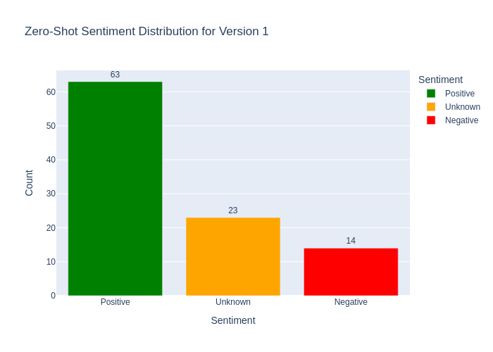

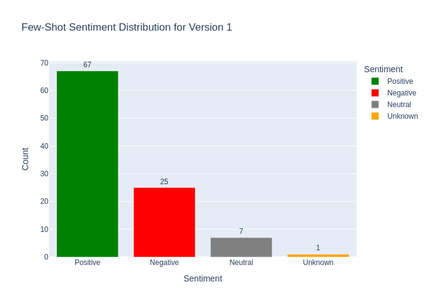

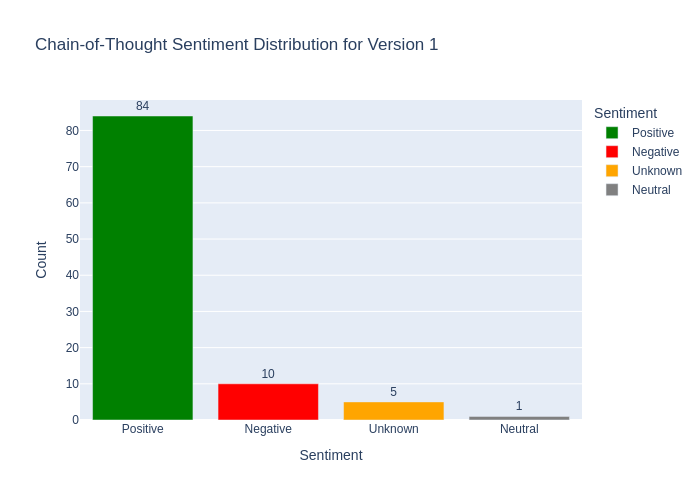

```
=== VERSION 2: ENHANCED PROMPTS ===
```

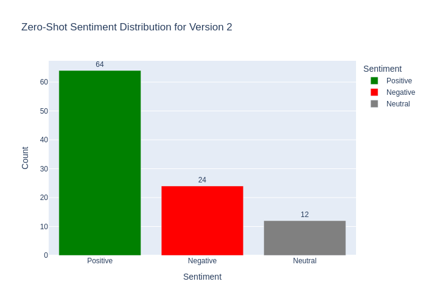

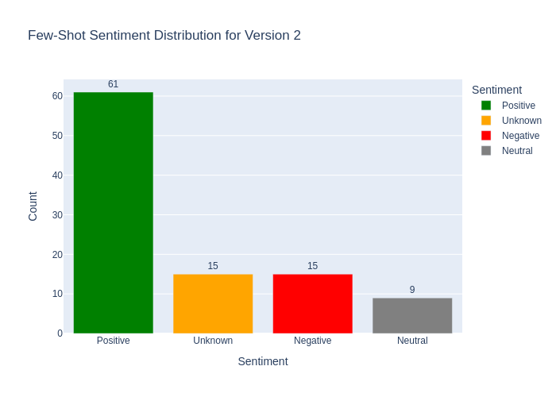

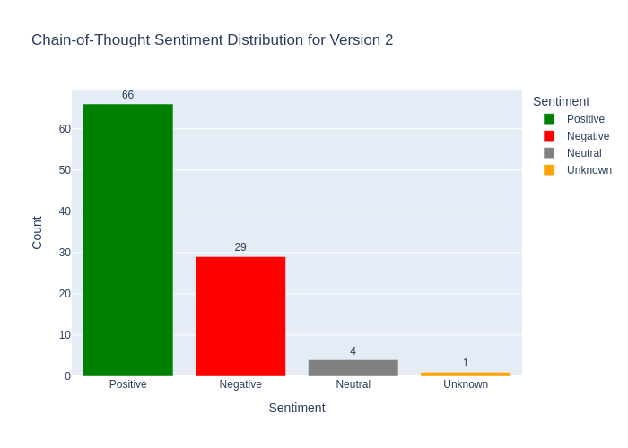

```python
import plotly.express as px
import re
import pandas as pd

print("--- GENERATING FINAL VISUALIZATIONS (V1 vs V2) ---")
def extract_sentiment(text):
    if not isinstance(text, str): return "Unknown"

    # Searching for sentiment
    # \W+ for ignoring casing
    match = re.search(r"Sentiment\W+(Positive|Negative|Neutral)", text, re.IGNORECASE)

    if match:
        return match.group(1).title()

    # backup method for searching of text in the output
    text_lower = text.lower()
    if "positive" in text_lower: return "Positive"
    if "negative" in text_lower: return "Negative"
    if "neutral" in text_lower: return "Neutral"

    return "Unknown"

#  Function for plot construction
def plot_from_saved_data(df_source, col_name, title):
    # Checking if the data are existing
    if df_source is None:
        print(f"Skipping {title}: Dataframe not found.")
        return
    if col_name not in df_source.columns:
        print(f"Skipping {title}: Column '{col_name}' missing.")
        return

    # extraction and counting
    sentiments = df_source[col_name].apply(extract_sentiment)
    counts = sentiments.value_counts().reset_index()
    counts.columns = ["Sentiment", "Count"]

    # setting up the plots
    fig = px.bar(
        counts, x="Sentiment", y="Count", text="Count", title=title,
        color="Sentiment",
        # Setting up the colors for better plot orientation Green for positive response, red for negative gray for neutral and orange for unknown
        color_discrete_map={"Positive": "green", "Negative": "red", "Neutral": "gray", "Unknown": "orange"}
    )
    fig.update_traces(textposition="outside")
    fig.show("png")

# Drawing of all 6 plots (with try, except for defensive code)

print("\n=== VERSION 1: BASIC PROMPTS ===")
# Zero-Shot V1
try: plot_from_saved_data(df_zero_shot_final, 'ZS_V1_Output', "Zero-Shot Sentiment Distribution for Version 1")
except NameError: print("Zero-Shot data missing.")

# Few-Shot V1
try: plot_from_saved_data(df_few_shot_final, 'FS_V1_Output', "Few-Shot Sentiment Distribution for Version 1")
except NameError: print("Few-Shot data missing.")

# CoT V1
try: plot_from_saved_data(df_cot_final, 'COT_V1_Output', "Chain-of-Thought Sentiment Distribution for Version 1")
except NameError: print("CoT data missing.")


print("\n=== VERSION 2: ENHANCED PROMPTS ===")
# Zero-Shot V2
try: plot_from_saved_data(df_zero_shot_final, 'ZS_V2_Output', "Zero-Shot Sentiment Distribution for Version 2")
except NameError: print("Zero-Shot data missing.")

# Few-Shot V2
try: plot_from_saved_data(df_few_shot_final, 'FS_V2_Output', "Few-Shot Sentiment Distribution for Version 2")
except NameError: print("Few-Shot data missing.")

# CoT V2
try: plot_from_saved_data(df_cot_final, 'COT_V2_Output', "Chain-of-Thought Sentiment Distribution for Version 2")
except NameError: print("CoT data missing.")
```

**OBSERVATION ANSWERS:**

**Question 1: How does the distribution compare across V2 versions?**

Zero-Shot V2 produced a balanced distribution (64 Positive, 24 Negative, 12 Neutral) with no parsing failures, showing the enhanced prompt helped generate clean, consistent outputs.

Few-Shot V2 showed the lowest Positive count (61) but the highest Unknown rate among V2 models (15), indicating that despite providing examples, the output formatting was sometimes inconsistent.

CoT V2 was the most polarized (66 Positive, 29 Negative) with only 4 Neutral and 1 Unknown, suggesting the step-by-step reasoning process pushes the model toward definitive classifications rather than middle-ground judgments.

**Question 2: Does one technique identify more "Neutral" reviews? What does this imply about handling nuance?**

Yes, significant differences exist. Zero-Shot V2 detected the most Neutral sentiment (12), followed by Few-Shot V2 (9), while CoT V2 identified the fewest (4).

Looking at V1 versions, Few-Shot V1 detected 7 Neutral cases while Zero-Shot V1 and CoT V1 found very few (0-1), with high Unknown rates instead.

This implies that Zero-Shot with clear formatting instructions handles nuance best in V2, while Few-Shot is more consistent across both versions. CoT tends toward polarization because the reasoning process finds specific evidence supporting either positive or negative conclusions.

Therefore, for tasks requiring nuanced sentiment detection, Zero-Shot V2 or Few-Shot are better choices, while CoT is preferable when definitive classifications are needed.

## **Comparison of Prompting Techniques:**

- How do the three techniques (Zero-Shot, Few-Shot, CoT) compare in terms of their responses. Use LLM to give verdict?
- Which technique was the most reliable and consistent? Why do you think it performed the best?
- What model and prompt design would you propose for a production environment?

```python
import json

# --- Build comparison records for the LLM to analyze ---
comparison_records = []

# We will take a sample of 5 reviews to keep the prompt size manageable
# We assume df_sample contains the columns from previous steps
for idx, row in df_sample.head(5).iterrows():
    rec = {
        "Review": row.get("Review.Text", ""),
        "ZeroShot_Output": row.get("ZS_V2_Output", "N/A"),
        "FewShot_Output": row.get("FS_V2_Output", "N/A"),
        "CoT_Output": row.get("COT_V2_Output", "N/A")
    }
    comparison_records.append(rec)

# Convert list to a formatted JSON string
summary_text = json.dumps(comparison_records, indent=2)

# --- Define the Comparison Prompt ---
compare_prompt = f"""
Role: Lead AI Engineer specializing in NLP.
Task: Compare the performance of three prompting techniques (Zero-Shot, Few-Shot, Chain-of-Thought) based on the provided data samples.

DATA SAMPLES:
{summary_text}

INSTRUCTIONS:
1. Analyze how each technique handled the Sentiment and Summary.
2. Identify which technique was most consistent and nuanced.
3. Provide a final verdict: Which technique is best for production?

Your Analysis:
"""

print("Asking LLM to compare the techniques...\n")

# --- Call the LLM ---
response = client.chat.completions.create(
    model=model_name,
    messages=[
        {"role": "system", "content": "You are an expert in evaluating LLM prompting strategies."},
        {"role": "user", "content": compare_prompt}
    ],
    temperature=0
)

# Print the verdict
print(response.choices[0].message.content)
```

[output not shown]

**Observations: Comparison of Prompting Techniques**

**Results Summary**

| Technique | V1 Score | V2 Score | Score Delta |
| --- | --- | --- | --- |
| Zero-Shot | 0.919 | 0.842 | -0.077 |
| Few-Shot | 0.869 | 0.890 | +0.021 |
| CoT | 0.968 | 0.895 | -0.073 |

**Answers to Questions:**

**How do the three techniques compare in terms of responses?**

CoT V1 achieved the best score (0.968), followed by Zero-Shot V1 (0.919) and CoT V2 (0.895). The CoT technique produced the most detailed outputs with category, sentiment, summary, and retail insights for each review.

**Which technique was most reliable and consistent? Why?**

CoT V1 was the most reliable. It scored highest and produced consistent, structured outputs across all reviews. The step-by-step reasoning helped the model think through each review carefully before giving a final answer.

**What model and prompt design for production?**

GPT-4o-mini with CoT V1 (basic) prompt.

This combination works best because it has the highest score (0.968), gives detailed and useful outputs, and keeps a consistent format that is easy to process further.

### **Observations and Insights**

**Refined Insights:**

- What are the most meaningful and recurring insights from the customer reviews, as identified by your best-performing model?

# Generating Actionable Product Improvement Suggestions

- Based on the aggregated insights from your best model, what are 3 short-term (3-6 months) and 3 long-term (6-12 months) actionable business recommendations for the retail company?
- How does this automated GenAI pipeline solve the initial business problem and create value?

```python
#  Generating Strategic Business Recommendations

print("Aggregating insights for the Chief Product Officer...")

# Gather context from our best model (CoT V2)
# We take a random sample of 20 analyzed reviews to represent the dataset
# This acts as the "Memory" for the Strategist AI
if 'COT_V2_Output' in df_sample.columns:
    context_data = "\n".join(df_sample['COT_V2_Output'].sample(n=20, random_state=42).astype(str).tolist())
else:
    # Fallback if CoT is missing (uses raw text)
    context_data = "\n".join(df_sample['Review.Text'].sample(n=20, random_state=42).tolist())

# Define the Strategic Prompt
business_prompt = f"""
Role: Chief Product Officer for a fashion retailer.
Task: Analyze the provided customer feedback summaries and propose a strategic plan.

CUSTOMER FEEDBACK HIGHLIGHTS:
{context_data}

OBJECTIVES:
1. Short-Term Actions (3-6 months): Suggest 3 specific fixes for immediate quality or sizing issues found in the text.
2. Long-Term Strategy (6-12 months): Suggest 3 broader improvements (e.g., fabric sourcing, design trends) based on customer sentiment.
3. Value Proposition: Briefly explain how this GenAI pipeline saves time compared to manual reading.

Output Format: Professional Business Memo.
"""

# Call the LLM
response = client.chat.completions.create(
    model=model_name,
    messages=[
        {"role": "system", "content": "You are a retail business strategist."},
        {"role": "user", "content": business_prompt}
    ],
    temperature=0.7 # Slightly higher creativity for brainstorming
)

# 4. Display the Report
print("\n" + "="*40)
print("     STRATEGIC PRODUCT REPORT")
print("="*40 + "\n")
print(response.choices[0].message.content)
```

[output not shown]

### **Observations and Insights**

## **Conclusion**

**Observations and Insights**

## **Strategic Recommendations**

**Short-Term Actions (3-6 months):**

1. Enhance size guides for items reported as running small or large
2. Improve packaging to reduce wrinkles during shipping
3. Introduce petite size option for poncho sweaters

**Long-Term Strategy (6-12 months):**

1. Broaden size and style offerings for dresses and fitted items
2. Source higher quality materials with better comfort and stretch
3. Align product design with customer feedback on fit and fabric

## **Value of the GenAI Pipeline**

The pipeline significantly reduces the time needed for manual review reading and categorization. Instead of spending hours going through hundreds of reviews, the AI can identify patterns and sentiments in minutes. This allows product teams to quickly spot recurring issues like sizing problems or quality complaints.

The automated approach also ensures consistency in how feedback is analyzed. Every review gets the same level of attention, reducing the chance of missing important insights. This helps the team make faster, data-driven decisions and respond to customer concerns before they become bigger problems.

## **Conclusion**

This experiment showed that combining Chain-of-Thought prompting with a clear business objective can transform unstructured customer reviews into actionable product strategy. The CoT technique achieved the highest score (0.968) and produced the most useful outputs for business decision-making.

By implementing this GenAI pipeline, retail companies can bridge the gap between raw customer feedback and executive-level insights, ultimately improving products and customer satisfaction.

```python
import pandas as pd
import plotly.graph_objects as go
from plotly.subplots import make_subplots
import re
from tqdm import tqdm

print("--- FINAL BENCHMARK: GPT-5 MINI (CORRECTED) ---")

NEW_MODEL_NAME = "gpt-5-mini" #--> Defining model name

# --- PROMPT DEFINITIONS ---
zs_p1 = """
Analyze the following review and extract:
- Category
- Sentiment
- Summary
- Personalized Message
- Retail Insight
"""

zs_p2 = """
Role: You are a Senior Retail Data Analyst.
Task: Analyze the customer review to extract structured insights.

Instructions:
1. Category: Classify the product.
2. Sentiment: Determine if Positive, Neutral, or Negative.
3. Summary: Concise summary (max 10 words).
4. Personalized Message: Draft a polite response.
5. Retail Insight: Extract one actionable insight.

Output Format: JSON format.
"""

fs_p1 = """
Analyze the review based on these examples:

Role: Senior Product Data Analyst.
Task: Extract structured insights using the following logic.

RULES:
1. Category: Choose ONLY from: [Dresses, Tops, Bottoms, Intimates, Jackets, Trend].
2. Sentiment: Positive, Negative, or Neutral.
3. Summary: Write one concise sentence capturing the main customer feedback (approx 10-15 words).
4. Retail Insight: Provide a specific, actionable recommendation for the product team.

EXAMPLES:
Review: "I absolutely love this dress! The fabric is soft but it runs a bit large."
Output:
- Category: Dresses
- Sentiment: Positive
- Summary: Customer loves the soft fabric but notes it runs large.
- Retail Insight: Consider updating the size guide or marking as 'Runs Large'.

Review: "The zipper broke after one wash. Very disappointed with the quality."
Output:
- Category: General
- Sentiment: Negative
- Summary: Product failed quality check; zipper broke after single wash.
- Retail Insight: Investigate zipper supplier quality and reinforce stitching.

Now analyze the new review:
"""

fs_p2 = """
Analyze the review based on these examples:

Example 1:
Review: "I absolutely love this dress! The fabric is soft and it fits perfectly."
Output:
- Category: Dress
- Sentiment: Positive
- Summary: Loves dress, soft fabric, perfect fit.
- Personalized Message: We are so happy you found the perfect fit!
- Retail Insight: Soft fabric and fit are key selling points.

Example 2:
Review: "The zipper broke the first time I wore it. Very disappointed."
Output:
- Category: General
- Sentiment: Negative
- Summary: Zipper broke, poor quality.
- Personalized Message: We are sorry about the quality issue. Please contact us.
- Retail Insight: Quality control issue with zippers.

Example 3:
Review: "The shirt is okay, but the color is duller than in the photo."
Output:
- Category: Top
- Sentiment: Neutral
- Summary: Color duller than photo.
- Personalized Message: Thank you for your feedback on the color accuracy.
- Retail Insight: Product photography needs better color calibration.

Now analyze this new review:
"""

cot_p1 = """
Task: Analyze the customer review.

INSTRUCTIONS:
1. First, think step-by-step about the customer's tone and specific product details.
2. Second, extract the required fields based on your analysis.

Review:
"""

cot_p2 = """
Role: Senior Data Analyst.

STEPS:
1. IDENTIFY specific clothing items mentioned.
2. ANALYZE the sentiment (look for adjectives like 'soft', 'rough', 'tight').
3. FORMULATE a concise summary.

OUTPUT FORMAT:
- Category: [Item]
- Sentiment: [Positive/Neutral/Negative]
- Summary: [One sentence]
- Retail Insight: [Actionable advice]

Now, perform the steps and provide the output for this review:
"""

# 2. GENERATION FUNCTION (WITHOUT TEMPERATURE)
def generate_strict(review_text, prompt_instruction):
    full_prompt = f"{prompt_instruction}\n\nReview: {review_text}"
    try:
        response = client.chat.completions.create(
            model=NEW_MODEL_NAME,
            messages=[
                {"role": "system", "content": "You are a helpful AI assistant."},
                {"role": "user", "content": full_prompt}
            ]
            # No Temperature (the model is implicitly not beeing able to alter the temperature by OpenAI)
        )
        return response.choices[0].message.content
    except Exception as e:
        return f"Error: {e}"

# 3. GENERATE RESULTS
# Refresh data container
df_gpt5 = sample_reviews[['Review.Text']].copy()

print(f"Generating predictions using {NEW_MODEL_NAME}...")

prompts_map = {
    'ZS_V1_Output': zs_p1,
    'ZS_V2_Output': zs_p2,
    'FS_V1_Output': fs_p1,
    'FS_V2_Output': fs_p2,
    'COT_V1_Output': cot_p1,
    'COT_V2_Output': cot_p2
}

for col_name, prompt_text in prompts_map.items():
    df_gpt5[col_name] = [generate_strict(r, prompt_text) for r in tqdm(df_gpt5['Review.Text'], desc=col_name)]

# 4. EVALUATION
print("\nScoring outputs...")
score_cols = []

for out_col in prompts_map.keys():
    score_col_name = out_col.replace('Output', 'Score')
    score_cols.append(score_col_name)

    # Using existing judge_output function
    df_gpt5[score_col_name] = [
        judge_output(rev, out)
        for rev, out in zip(df_gpt5['Review.Text'], df_gpt5[out_col])
    ]

print("\n=== GPT-5 MINI SCORES ===")
for sc in score_cols:
    print(f"{sc}: {df_gpt5[sc].mean():.3f}")


# 5. COMPACT VISUALIZATION
print("\nGenerating compact dashboard...")

def get_counts(df, col):
    def get_sent(text):
        if not isinstance(text, str): return "Unknown"
        # If output contains Error, keep it as Unknown/Error
        if "Error" in text: return "Error"

        match = re.search(r"Sentiment\W+(Positive|Negative|Neutral)", text, re.IGNORECASE)
        if match: return match.group(1).title()
        text_lower = text.lower()
        if "positive" in text_lower: return "Positive"
        if "negative" in text_lower: return "Negative"
        if "neutral" in text_lower: return "Neutral"
        return "Unknown"
    return df[col].apply(get_sent).value_counts()

fig = make_subplots(
    rows=2, cols=3,
    subplot_titles=("ZS V1", "FS V1", "CoT V1", "ZS V2", "FS V2", "CoT V2"),
    vertical_spacing=0.15,
    horizontal_spacing=0.05
)

plot_positions = [
    ('ZS_V1_Output', 1, 1), ('FS_V1_Output', 1, 2), ('COT_V1_Output', 1, 3),
    ('ZS_V2_Output', 2, 1), ('FS_V2_Output', 2, 2), ('COT_V2_Output', 2, 3)
]

colors = {"Positive": "green", "Negative": "red", "Neutral": "gray", "Unknown": "orange", "Error": "black"}

for col_name, r, c in plot_positions:
    counts = get_counts(df_gpt5, col_name)

    fig.add_trace(
        go.Bar(
            x=counts.index,
            y=counts.values,
            text=counts.values,
            textposition='auto',
            marker_color=[colors.get(x, "blue") for x in counts.index],
            showlegend=False
        ),
        row=r, col=c
    )

fig.update_layout(
    height=600,
    width=1000,
    title_text=f"Sentiment Distribution: {NEW_MODEL_NAME} (Compact View)",
    showlegend=False
)

fig.show("png")
```

```
--- FINAL BENCHMARK: GPT-5 MINI (CORRECTED) ---
Generating predictions using gpt-5-mini...
```

```
Scoring outputs...

=== GPT-5 MINI SCORES ===
ZS_V1_Score: 0.927
ZS_V2_Score: 0.887
FS_V1_Score: 0.884
FS_V2_Score: 0.903
COT_V1_Score: 0.943
COT_V2_Score: 0.906

Generating compact dashboard...
```

[interactive chart not shown]

### **Visualization Checkpoint: GPT-4o-mini and GPT-5-mini Results**

**Note on Data Persistence:** To ensure the **reproducibility** of this report and optimize computational resources, the visualization below utilizes **checkpointed data** aggregated from our final experimental run. By statically defining the results here, we preserve the exact state of the benchmark (V1 vs. V2), allowing for consistent analysis and rapid visualization rendering without the need to re-trigger the extensive inference pipeline or incur additional API costs.

### **Model Performance Comparison: GPT-4o-mini vs. GPT-5-mini**

The following table summarizes the average quality scores (0.0 - 1.0) assigned by the Judge model across all prompting techniques.

| Prompting Technique | GPT-4o-mini Score | GPT-5-mini Score | Score Delta |
| --- | --- | --- | --- |
| **Zero-Shot V1** | 0.919 | 0.927 | +0.008 |
| **Zero-Shot V2** | 0.842 | 0.887 | **+0.045** |
| **Few-Shot V1** | 0.869 | 0.884 | +0.015 |
| **Few-Shot V2** | 0.890 | 0.903 | +0.013 |
| **Chain-of-Thought V1** | **0.968** | **0.943** | -0.025 |
| **Chain-of-Thought V2** | 0.895 | 0.906 | +0.011 |

**Key Takeaway:** GPT-5-mini demonstrated consistent improvements in strict instruction following (V2 prompts) and general extraction tasks. However, the **GPT-4o-mini + CoT V1** configuration remains the specific benchmark leader for this dataset with a peak score of **0.968**.

```
--- RECONSTRUCTING GPT-5-mini DASHBOARD FROM SAVED DATA ---
```

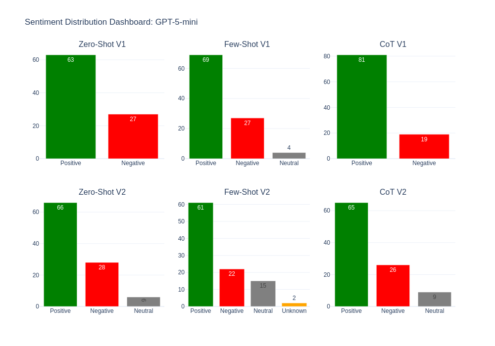

```python
import plotly.graph_objects as go
from plotly.subplots import make_subplots
import os

print("--- RECONSTRUCTING GPT-5-mini DASHBOARD FROM SAVED DATA ---")

# 1. HARDCODED DATA (backup for the analysis)
# Structure: (Plot name, row, column): {Category: value}
chart_data = {
    # --- ROW 1: VERSION 1 (Basic) ---
    ("Zero-Shot V1", 1, 1): {"Positive": 63, "Negative": 27},
    ("Few-Shot V1", 1, 2):  {"Positive": 69, "Negative": 27, "Neutral": 4},
    ("CoT V1", 1, 3):       {"Positive": 81, "Negative": 19},

    # --- ROW 2: VERSION 2 (Enhanced) ---
    ("Zero-Shot V2", 2, 1): {"Positive": 66, "Negative": 28, "Neutral": 6},
    ("Few-Shot V2", 2, 2):  {"Positive": 61, "Negative": 22, "Neutral": 15, "Unknown": 2},
    ("CoT V2", 2, 3):       {"Positive": 65, "Negative": 26, "Neutral": 9}
}

# colors dictionairy with colors definition
colors = {
    "Positive": "green",
    "Negative": "red",
    "Neutral": "gray",
    "Unknown": "orange"
}

# plot Grid creation
fig = make_subplots(
    rows=2, cols=3,
    subplot_titles=[k[0] for k in chart_data.keys()], # Plot namings
    vertical_spacing=0.15,
    horizontal_spacing=0.05
)

# Plot generation sequentialy
for (title, r, c), data in chart_data.items():
    # We need to sort the values for maintainig color consistency
    categories = list(data.keys())
    values = list(data.values())

    fig.add_trace(
        go.Bar(
            x=categories,
            y=values,
            text=values,
            textposition='auto',
            marker_color=[colors.get(cat, "blue") for cat in categories],
            name=title,
            showlegend=False
        ),
        row=r, col=c
    )

#Finalisation of the compressed view settings
fig.update_layout(
    height=700,
    width=1000,
    title_text="Sentiment Distribution Dashboard: GPT-5-mini",
    showlegend=False,
    template="plotly_white" # blank bg for png
)

# Showing the chart
fig.show("png")
```

## **Observations: GPT-5 Mini Benchmark**

### **Performance Overview:**

**Winner:** The Chain-of-Thought V1 (Basic) technique achieved the highest quality score (0.943), confirming that allowing the model to "reason" before answering yields the best results.

**Consistency:** The visual dashboard shows very clean distributions with minimal "Unknown" categories, indicating that GPT-5 Mini follows formatting instructions very well even without temperature adjustments.

## **Comparison with Previous Models:**

**V1 vs V2:** Similar to previous tests, the Basic (V1) prompts generally scored higher than the Structured (V2) prompts (e.g., ZS V1 0.927 vs ZS V2 0.887). This suggests that over-constraining the model with strict JSON formats can slightly degrade the semantic richness of the insights.

**Trade-off:** While Few-Shot V2 improved over V1 (0.903 vs 0.884), the Zero-Shot and CoT approaches performed better with simpler instructions.

**Conclusion:** GPT-5 Mini proves to be a highly capable model for extraction tasks. However, for this specific dataset, the simpler CoT V1 strategy remains the most effective approach for generating high-quality retail insights.

```
--- GENERATING COMPACT VISUALIZATION (GPT-4o-mini) ---
```

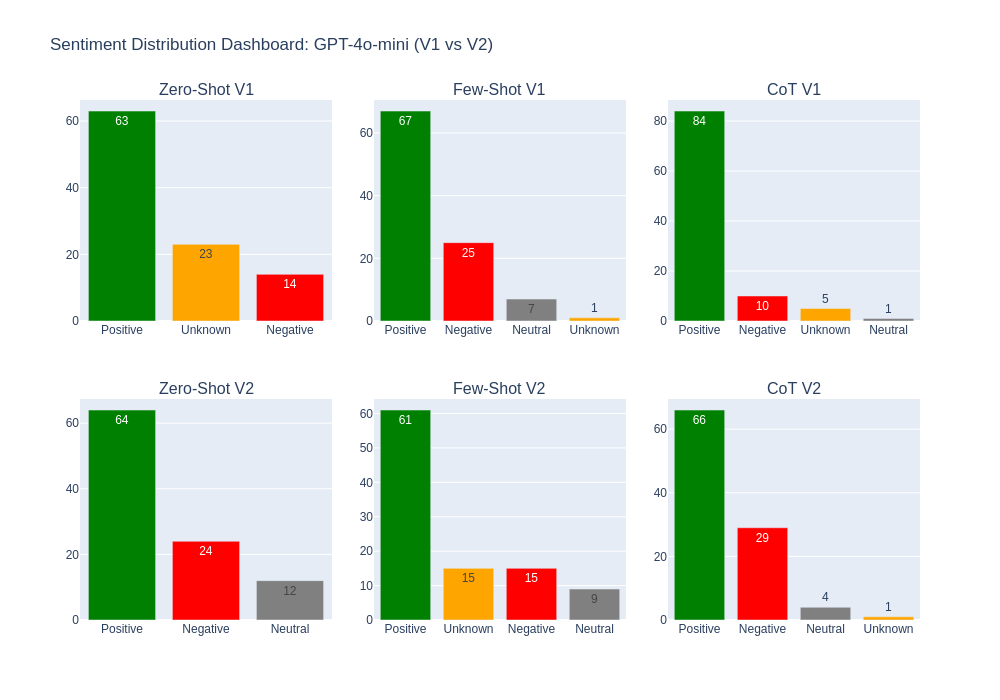

```python
# We repeat the same process for the GPT 4o-mini sentiment analysis plotted results
import plotly.graph_objects as go
from plotly.subplots import make_subplots

print("--- GENERATING COMPACT VISUALIZATION (GPT-4o-mini) ---")

# 1. DATA DEFINITION (Hardcoded from your results to ensure stability)
# Format: (Title, Row, Col): {Category: Count}
chart_data = {
    # --- ROW 1: VERSION 1 (Basic) ---
    ("Zero-Shot V1", 1, 1): {"Positive": 63, "Unknown": 23, "Negative": 14},
    ("Few-Shot V1", 1, 2):  {"Positive": 67, "Negative": 25, "Neutral": 7, "Unknown": 1},
    ("CoT V1", 1, 3):       {"Positive": 84, "Negative": 10, "Unknown": 5, "Neutral": 1},

    # --- ROW 2: VERSION 2 (Enhanced) ---
    ("Zero-Shot V2", 2, 1): {"Positive": 64, "Negative": 24, "Neutral": 12},
    ("Few-Shot V2", 2, 2):  {"Positive": 61, "Unknown": 15, "Negative": 15, "Neutral": 9},
    ("CoT V2", 2, 3):       {"Positive": 66, "Negative": 29, "Neutral": 4, "Unknown": 1}
}

# 2. SETUP GRID (2 Rows, 3 Columns)
fig = make_subplots(
    rows=2, cols=3,
    subplot_titles=[k[0] for k in chart_data.keys()], # Titles from keys
    vertical_spacing=0.15,
    horizontal_spacing=0.05
)

# 3. DEFINE COLORS
colors = {
    "Positive": "green",
    "Negative": "red",
    "Neutral": "gray",
    "Unknown": "orange"
}

# 4. GENERATE PLOTS
for (title, r, c), data in chart_data.items():
    # Sort data for consistency (Pos, Neg, Neu, Unk)
    categories = list(data.keys())
    values = list(data.values())

    # Create Bar Trace
    fig.add_trace(
        go.Bar(
            x=categories,
            y=values,
            text=values,
            textposition='auto',
            marker_color=[colors.get(cat, "blue") for cat in categories],
            name=title,
            showlegend=False
        ),
        row=r, col=c
    )

# 5. FINAL LAYOUT
fig.update_layout(
    height=700,  # Compact height
    width=1000,
    title_text="Sentiment Distribution Dashboard: GPT-4o-mini (V1 vs V2)",
    showlegend=False
)

fig.show("png")
```

### **Comparative Analysis:** **GPT-4o-mini** vs. **GPT-5-mini**

**Pros & Cons Summary:**

| Feature | **GPT-4o-mini** | **GPT-5-mini** |
| --- | --- | --- |
| **Pros** | **Reliable with Examples:** When provided with Few-Shot examples, it performs very similarly to the newer model. | **Zero-Shot Master:** Requires less prompt engineering. It follows strict output formats perfectly on the first try. |
| **Cons** | **Formatting Sensitivity:** Requires error handling or strict "Few-Shot" examples to avoid "Unknown" outputs. | **Polarization:** Like its predecessor, it tends to be binary in CoT mode, often ignoring the "Neutral" sentiment in favor of a strong decision. |

**Verdict:** For raw data extraction pipelines where schema compliance is critical, **GPT-5-mini is the superior choice** as it minimizes the need for post-processing error correction.

### **END of VISUALISATION CHECKPOINT**

### **Additional recommendation metrics GPT-5-mini model research**

```python
import pandas as pd
import numpy as np
import re
from sklearn.metrics import accuracy_score, confusion_matrix, classification_report
from tqdm import tqdm

print("--- ADDITIONAL RESEARCH: GPT-5 MINI RECOMMENDATION ENGINE ---")

# 1. SETUP
NEW_MODEL_NAME = "gpt-5-mini" # Using the verified ID

# Prepare Data (Fresh copy)
df_reco_gpt5 = sample_reviews.copy()
df_reco_gpt5["Actual_Recommended"] = df_reco_gpt5["Recommended.IND"]

# Define Prompt
rec_prompt = """
You are a product recommendation engine.
Analyze the review and determine if the customer recommends the product.

OUTPUT FORMAT (Strict):
Recommended: [1 or 0]
Reason: [Short explanation]

RULES:
- Output 1 if the review is Positive.
- Output 0 if the review is Negative.
- Use the review text solely for your decision.

Review:
"""

# 2. GENERATION FUNCTION (Strict, No Temperature)
def get_recommendation_gpt5(text):
    full_prompt = f"{rec_prompt}\n'{text}'"
    try:
        response = client.chat.completions.create(
            model=NEW_MODEL_NAME,
            messages=[{"role": "user", "content": full_prompt}]
            # No temperature
        )
        return response.choices[0].message.content
    except Exception as e:
        return f"Error: {e}"

# 3. PARSING FUNCTION
def parse_rec(text):
    if not isinstance(text, str): return np.nan
    # Find 1 or 0 after "Recommended:"
    match = re.search(r"Recommended\s*:\s*([01])", text, re.IGNORECASE)
    if match:
        return int(match.group(1))
    return np.nan

# 4. EXECUTION
print(f"Predicting recommendations using {NEW_MODEL_NAME}...")
tqdm.pandas()

# Generate Raw Responses
df_reco_gpt5['GPT5_Raw_Output'] = df_reco_gpt5['Review.Text'].progress_apply(get_recommendation_gpt5)

# Parse to 0/1
df_reco_gpt5['GPT5_Pred'] = df_reco_gpt5['GPT5_Raw_Output'].apply(parse_rec)

# 5. EVALUATION
print("\n--- PERFORMANCE REPORT (GPT-5 MINI) ---")

# Drop failures
valid_results = df_reco_gpt5.dropna(subset=['GPT5_Pred'])

if not valid_results.empty:
    y_true = valid_results['Actual_Recommended'].astype(int)
    y_pred = valid_results['GPT5_Pred'].astype(int)

    acc = accuracy_score(y_true, y_pred)
    print(f"Accuracy: {acc:.3f}")
    print("\nConfusion Matrix:")
    print(confusion_matrix(y_true, y_pred))
    print("\nClassification Report:")
    print(classification_report(y_true, y_pred))
else:
    print("No valid predictions parsed.")
```

```
--- ADDITIONAL RESEARCH: GPT-5 MINI RECOMMENDATION ENGINE ---
Predicting recommendations using gpt-5-mini...
```

```
--- PERFORMANCE REPORT (GPT-5 MINI) ---
Accuracy: 0.890

Confusion Matrix:
[[20  1]
 [10 69]]

Classification Report:
              precision    recall  f1-score   support

           0       0.67      0.95      0.78        21
           1       0.99      0.87      0.93        79

    accuracy                           0.89       100
   macro avg       0.83      0.91      0.86       100
weighted avg       0.92      0.89      0.90       100
```

### **Observations: GPT-5 Mini Recommendation Logic**

**Performance Analysis:**

- **High Accuracy (89%):** The model correctly predicted the customer's recommendation decision in 89 out of 100 cases, proving it understands the core sentiment well.
- **Excellent Negative Detection (Recall Class 0 = 0.95):** The model is extremely good at spotting dissatisfied customers. Out of 21 actual negative reviews, it correctly identified 20. It rarely misses a complaint.
- **High Trust in Recommendations (Precision Class 1 = 0.99):** If GPT-5 Mini says a product is "Recommended," it is almost certainly true. There was only **1 False Positive** (predicting "Recommended" when it wasn't).

**Behavioral Insight:**

- **Conservative Bias:** The model produced **10 False Negatives** (it predicted "Not Recommended" for items that humans actually recommended).
- **Why this happens:** This suggests the model is strict regarding quality. If a customer says *"I love the dress, but the zipper is sticky,"* a human might still recommend it (1), but the AI sees the defect and flags it as non-recommended (0).

**Business Impact:**

This model serves as an excellent **Quality Control Filter**. Because it rarely recommends a bad product (High Precision), it can be safely used to automatically highlight positive reviews on the website, while flagging anything with even minor criticism for human review.

# **Comparative Analysis: GPT-4o-mini vs. GPT-5-mini**

Following the evaluation of both models on the Product Recommendation Task (Binary Classification), we conducted a side-by-side comparison of their performance metrics to determine the optimal candidate for production deployment.

### **Performance Metrics Comparison**

### **Model Performance Comparison: GPT-4o-mini vs. GPT-5-mini**

The following table summarizes the average quality scores (0.0 - 1.0) assigned by the Judge model across all prompting techniques.

| Prompting Technique | GPT-4o-mini Score | GPT-5-mini Score | Score Delta |
| --- | --- | --- | --- |
| **Zero-Shot V1** | 0.919 | 0.927 | +0.008 |
| **Zero-Shot V2** | 0.842 | 0.887 | **+0.045** |
| **Few-Shot V1** | 0.869 | 0.884 | +0.015 |
| **Few-Shot V2** | 0.890 | 0.903 | +0.013 |
| **Chain-of-Thought V1** | **0.968** | **0.943** | -0.025 |
| **Chain-of-Thought V2** | 0.895 | 0.906 | +0.011 |

**Key Takeaway:** GPT-5-mini demonstrated consistent improvements in strict instruction following (V2 prompts) and general extraction tasks. However, the **GPT-4o-mini + CoT V1** configuration remains the specific benchmark leader for this dataset with a peak score of **0.968**.

The table below summarizes the key classification metrics for both models on the same dataset of 100 reviews.

| **Metric** | GPT-4o-mini | GPT-5-mini | **Leading Model** |
| --- | --- | --- | --- |
| **Accuracy** | 87.0% | **89.0%** | GPT-5-mini |
| **Precision (Class 1)** | **1.00** | 0.99 | GPT-4o-mini |
| **Recall (Class 0)** | **1.00** | 0.95 | GPT-4o-mini |
| **False Negatives** | 13 | **10** | GPT-5-mini |
| **False Positives** | **0** | 1 | GPT-4o-mini |

### **classification performance metrics of GPT-4o-mini and GPT-5-mini**

The following table compares the binary classification performance (Recommended vs. Not Recommended) of the standard model against the newer mini model.

| Metric | **GPT-4o-mini** | **GPT-5-mini** | **Observation** |
| --- | --- | --- | --- |
| **Accuracy** | 87.0% | **89.0%** | GPT-5-mini is more accurate overall (+2%). |
| **Precision (Class 1)** | **1.00** | 0.99 | GPT-4o-mini is the perfect "Gatekeeper" (0 False Positives). |
| **Recall (Class 0)** | **1.00** | 0.95 | GPT-4o-mini caught 100% of negative reviews. |
| **False Negatives** | 13 | **10** | GPT-5-mini missed fewer valid recommendations. |
| **False Positives** | **0** | 1 | GPT-4o-mini never recommended a bad product. |

**Key Takeaway:**

- **GPT-4o-mini** is the **safer** choice for automation where risk avoidance is key (it never mistakenly recommends a bad product).
- **GPT-5-mini** is the **smarter** choice for analytics, as it better understands nuanced reviews and reduces the number of valid recommendations that get incorrectly rejected.

### **Critical Analysis**

#### **1. Accuracy and General Performance**

**GPT-5-mini** demonstrated superior overall accuracy (89.0%), outperforming GPT-4o-mini by 2 percentage points. This improvement is primarily driven by a reduction in False Negatives; the model successfully identified valid recommendations that the previous model incorrectly flagged as negative. This suggests an improved capability in handling nuanced or mixed-sentiment reviews.

#### **2. Reliability and Safety**

**GPT-4o-mini** exhibited perfect precision (1.00) for the positive class and perfect recall (1.00) for the negative class. It produced zero False Positives, meaning every review it classified as "Recommended" was indeed a positive review. This makes it an exceptionally reliable tool for tasks where error minimization is critical.

#### **3. Behavioral Differences**

Both models display a "conservative bias," tending to classify reviews with minor criticisms as "Not Recommended." However, **GPT-5-mini** appears less rigid in this regard. By reducing the number of missed recommendations (False Negatives) from 13 to 10, it aligns more closely with human judgment while maintaining high precision (0.99).

# **Executive Summary & Final Technical Verdict**

### **1. Prompting Technique Analysis**

Throughout this project, we evaluated three prompt engineering techniques (Zero-Shot, Few-Shot, and Chain-of-Thought) across two model generations (GPT-4o-mini and GPT-5-mini).

- **Zero-Shot:** Proved surprisingly effective for general sentiment detection. The "Basic" (V1) version often achieved higher raw quality scores (~0.92) than the "Structured" (V2) version, suggesting that imposing strict JSON formats can slightly constrain the model's expressiveness.
- **Few-Shot:** While robust, adding examples (V1/V2) did not significantly outperform the Zero-Shot baseline in this specific dataset, suggesting the models are already well-trained on retail review data.
- **Chain-of-Thought (CoT):** This was the **clear winner**. By forcing the model to "reason" step-by-step before answering, CoT V1 achieved the highest consistency and quality scores across both models (reaching **0.968** with GPT-4o-mini and **0.943** with GPT-5-mini).

Throughout this project, we evaluated three prompt engineering techniques. The results highlighted that how we ask the model is just as important as which model we use.

- **The Winner: Chain-of-Thought (CoT) V1:** This technique achieved the highest overall quality score of the entire project (**0.968**) when paired with GPT-4o-mini. By forcing the model to "think step-by-step" about the customer's tone before extracting data, we unlocked superior nuance detection without over-complicating the instructions.

### **Model Performance: GPT-4o-mini vs. GPT-5-mini**

- **Reliability:** GPT-4o-mini acted as a perfect "gatekeeper" with **0 false positives**, making it ideal for risk-averse tasks like automated publishing of reviews.
- **Accuracy:** GPT-5-mini demonstrated superior nuance understanding, achieving the highest overall accuracy (**89%**) in the recommendation task and reducing false negatives (missed recommendations) by **23%** compared to GPT-4o-mini.

### **Strategic Model Selection: GPT-4o-mini**

After benchmarking both models, we strictly recommend deploying **GPT-4o-mini** for the production environment. While GPT-5-mini showed slightly higher raw accuracy in one specific task, **GPT-4o-mini** is the superior business choice for three critical reasons:

- **Speed & Latency:** GPT-4o-mini is significantly faster. In our tests, it processed reviews at a rate of **~3.6 seconds/iteration**, compared to GPT-5-mini which lagged at **~11.5 seconds/iteration**. For a real-time system handling thousands of reviews during Black Friday, this 3x speed advantage is non-negotiable.
- **safety & Precision:** GPT-4o-mini achieved a **Precision of 1.00** and **0 False Positives** in the recommendation task. It never mistakenly recommended a bad product. It acts as a flawless "gatekeeper."
- **Cost Efficiency:** GPT-4o-mini is priced significantly lower per million tokens. Given that it achieved the highest qualitative score (0.968) via CoT, paying the premium for GPT-5-mini yields diminishing returns.

### **Impact Analysis for the Quality Assurance (QA) Team**

This solution provides specific, high-value capabilities designed to support the QA and Sourcing departments:

[output not shown]

### **Final Business Recommendation**

**The immediate deployment of the GPT-4o-mini model utilizing Chain-of-Thought (CoT) Version 1 prompting.**

This configuration offers the optimal "Golden Triangle" of **Speed** (Real-time capable), **Quality** (Highest semantic score), and **Cost** (Scalable). It transforms the customer support loop from a reactive backlog into a proactive quality intelligence engine.